# Avancement GSCA - 12/06/2026

### 3.1.8 graphes

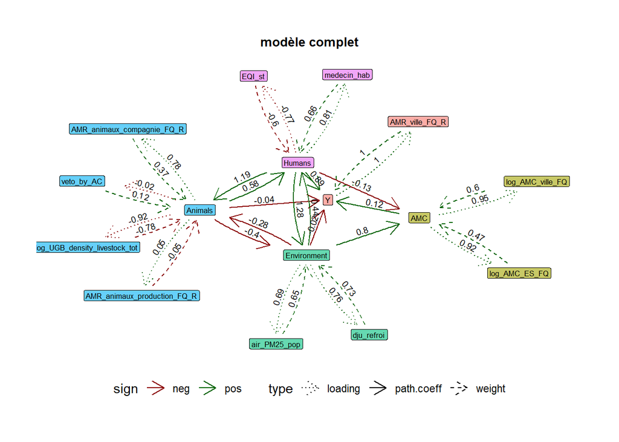

```r
#-----------------------
# construire le dataset
#-----------------------

# les paths
paths$from <- str_remove(paths$term, ".*~")
paths2 <- paths %>%
  dplyr::rename(to = "outcome") %>%
  dplyr::select(from, to, estimate, model) %>%
  dplyr::mutate(sign = ifelse(estimate >=0, "pos", "neg")) %>%
  dplyr::mutate(block = from) %>%
  dplyr::mutate(type = "path.coeff")
# les weights
weights2 <- weights %>%
  dplyr::rename(from = "term", to = "block") %>%
  dplyr::select(from, to, estimate, model) %>%
  dplyr::mutate(sign = ifelse(estimate >=0, "pos", "neg")) %>%
  dplyr::mutate(block = to) %>%
  dplyr::mutate(type = "weight")
# les loadings
loadings2 <- loadings %>%
  dplyr::rename(from = "block", to = "term") %>%
  dplyr::select(from, to, estimate, model) %>%
  dplyr::mutate(sign = ifelse(estimate >=0, "pos", "neg")) %>%
  dplyr::mutate(block = from) %>%
  dplyr::mutate(type = "loading")

dat_graph <- rbind(paths2, weights2, loadings2)

#----------------------
# modèle complet
#----------------------

dat_filtered <- dat_graph %>%
  dplyr::filter(model == "complet")

# Construire le tableau des noeuds avec leur block
nodes_df <- dplyr::bind_rows(
  dat_filtered %>% dplyr::select(name = from, block),
  dat_filtered %>% dplyr::select(name = to, block)
) %>%
  dplyr::filter(!is.na(block)) %>%   # garde les lignes où block est renseigné
  dplyr::distinct(name, .keep_all = TRUE)  # une ligne par noeud

# Construire le graphe explicitement
graph <- tbl_graph(
  nodes = nodes_df,
  edges = dat_filtered %>% dplyr::select(from, to, estimate, sign, type),
  node_key = "name"
)

g1 <- ggraph(graph) +
  geom_edge_fan(aes(colour = sign,
                     end_cap = label_rect(node2.name),
                     start_cap = label_rect(node1.name),
                    label = round(estimate, 2),
                    linetype = type),
                arrow = arrow(length = unit(4, 'mm')),
                label_dodge = unit(1.8, 'mm'),
                angle_calc = "along",
                label_size = 2.5) +
  geom_node_label(aes(label = name, fill = block), size = 2.2,
                  show.legend = FALSE, alpha = 0.6) +
  labs(title = "modèle complet")+
  scale_x_continuous(expand = expansion(mult = 0.10)) +
  ggraph::theme_graph(background = 'white') +
  theme(legend.position = "bottom") +
  theme(plot.title = element_text(hjust = 0.5, size = 10))+
  scale_edge_colour_manual(values = c("darkred", "darkgreen"))+
  scale_edge_linetype_manual(values = c(path.coeff = "solid", weight = "dashed", loading = "dotted"))+
  scale_fill_manual(values = c(Y = "#F8766D", Animals = "#00B0F6", Humans = "#E76BF3",
                  Environment = "#00BF7D", AMC = "#A3A500"))

#----------------------
# modèle intermédiaire
#----------------------

dat_filtered <- dat_graph %>%
  dplyr::filter(model == "int")

# Construire le tableau des noeuds avec leur block
nodes_df <- dplyr::bind_rows(
  dat_filtered %>% dplyr::select(name = from, block),
  dat_filtered %>% dplyr::select(name = to, block)
) %>%
  dplyr::filter(!is.na(block)) %>%   # garde les lignes où block est renseigné
  dplyr::distinct(name, .keep_all = TRUE)  # une ligne par noeud

# Construire le graphe explicitement
graph <- tbl_graph(
  nodes = nodes_df,
  edges = dat_filtered %>% dplyr::select(from, to, estimate, sign, type),
  node_key = "name"
)

g2 <- ggraph(graph) +
  geom_edge_fan(aes(colour = sign,
                     end_cap = label_rect(node2.name),
                     start_cap = label_rect(node1.name),
                    label = round(estimate, 2),
                    linetype = type),
                arrow = arrow(length = unit(4, 'mm')),
                label_dodge = unit(1.8, 'mm'),
                angle_calc = "along",
                label_size = 2.5) +
  geom_node_label(aes(label = name, fill = block), size = 2.2,
                  show.legend = FALSE, alpha = 0.6) +
  labs(title = "modèle intermédiaire")+
  ggraph::theme_graph(background = 'white') +
  theme(legend.position = "bottom") +
  scale_x_continuous(expand = expansion(mult = 0.10)) +
  theme(plot.title = element_text(hjust = 0.5, size = 10))+
  scale_edge_colour_manual(values = c("darkred", "darkgreen"))+
  scale_edge_linetype_manual(values = c(path.coeff = "solid", weight = "dashed", loading = "dotted"))+
  scale_fill_manual(values = c(Y = "#F8766D", Animals = "#00B0F6", Humans = "#E76BF3",
                  Environment = "#00BF7D", AMC = "#A3A500"))

#----------------------
# modèle simple
#----------------------

dat_filtered <- dat_graph %>%
  dplyr::filter(model == "simple")

# Construire le tableau des noeuds avec leur block
nodes_df <- dplyr::bind_rows(
  dat_filtered %>% dplyr::select(name = from, block),
  dat_filtered %>% dplyr::select(name = to, block)
) %>%
  dplyr::filter(!is.na(block)) %>%   # garde les lignes où block est renseigné
  dplyr::distinct(name, .keep_all = TRUE)  # une ligne par noeud

# Construire le graphe explicitement
graph <- tbl_graph(
  nodes = nodes_df,
  edges = dat_filtered %>% dplyr::select(from, to, estimate, sign, type),
  node_key = "name"
)

g3 <- ggraph(graph) +
  geom_edge_fan(aes(colour = sign,
                     end_cap = label_rect(node2.name),
                     start_cap = label_rect(node1.name),
                    label = round(estimate, 2),
                    linetype = type),
                arrow = arrow(length = unit(4, 'mm')),
                label_dodge = unit(1.8, 'mm'),
                angle_calc = "along",
                label_size = 2.5) +
  geom_node_label(aes(label = name, fill = block), size = 2.2,
                  show.legend = FALSE, alpha = 0.6) +
  labs(title = "modèle simple")+
  scale_x_continuous(expand = expansion(mult = 0.10)) +
  ggraph::theme_graph(background = 'white') +
  theme(legend.position = "bottom") +
  theme(plot.title = element_text(hjust = 0.5, size = 10))+
  scale_edge_colour_manual(values = c("darkred", "darkgreen"))+
  scale_edge_linetype_manual(values = c(path.coeff = "solid", weight = "dashed", loading = "dotted"))+
  scale_fill_manual(values = c(Y = "#F8766D", Animals = "#00B0F6", Humans = "#E76BF3",
                  Environment = "#00BF7D", AMC = "#A3A500"))

g1
```

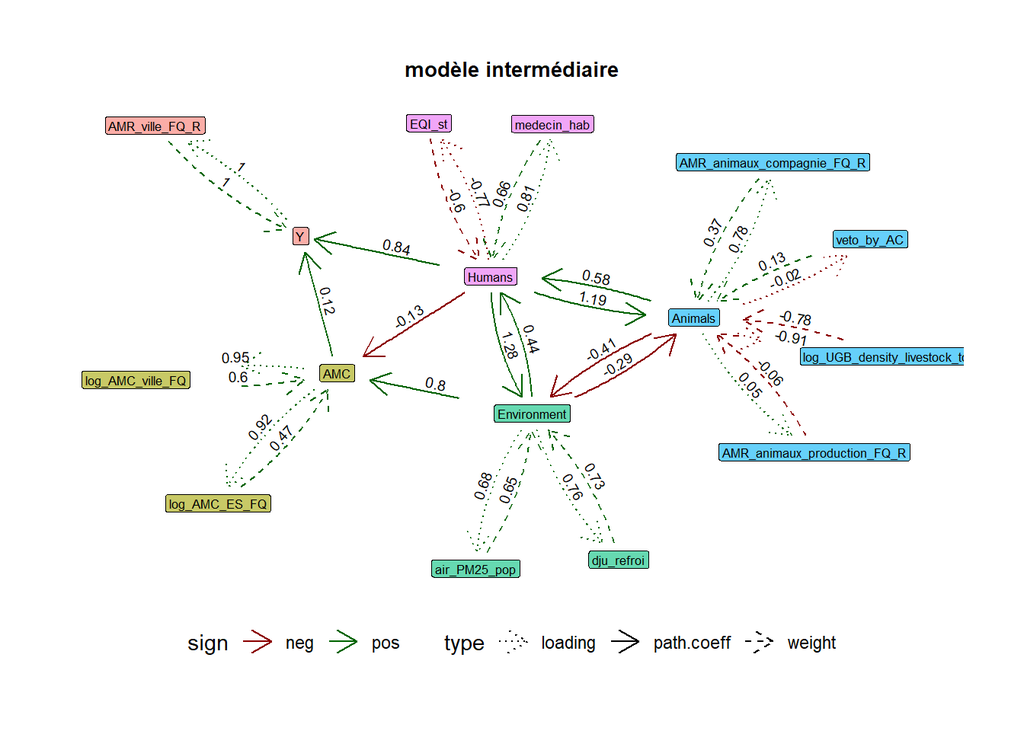

```r
g2
```

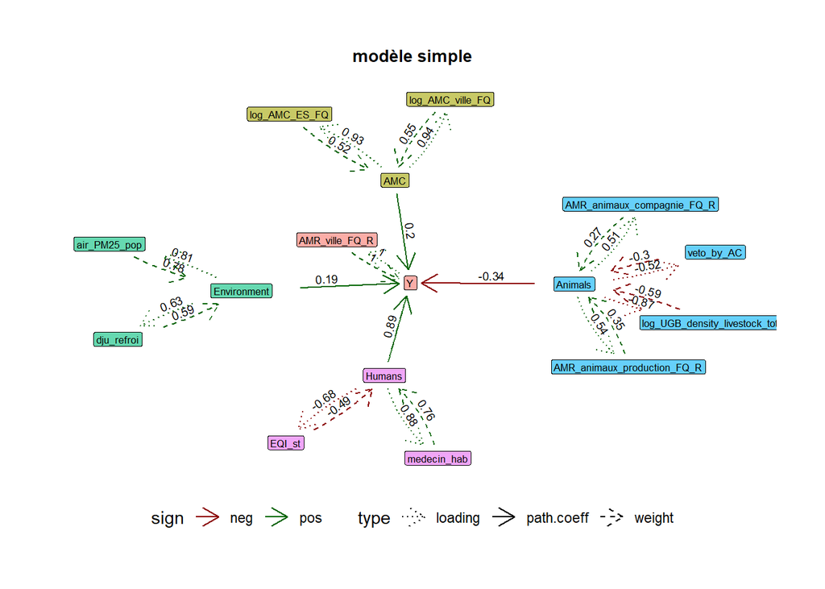

```r
g3
```

### 3.1.9 Coefficients de régression

**On considère ici seulement le modèle intermédaire car c’est celui-là qu’on a choisi de présenter.**

Comme ce qu’on a pu déjà constater en regardant le graphe. Ce n’est pas la consommation d’antibiotique sur la même année qui a l’air de jouer principalement sur la résisantce aux fluoroquinolones. Mais plutôt le nombre de médecin par habitants et l’EQI. Visiblement, le nombre de medecin s’explique par si la région est urbaine ou rurale (beaucoup de pollution et peu d’animaux de production impliquent beaucoup de médecins parce que région urbanisée) et l’EQI aussi mais à l’inverse.

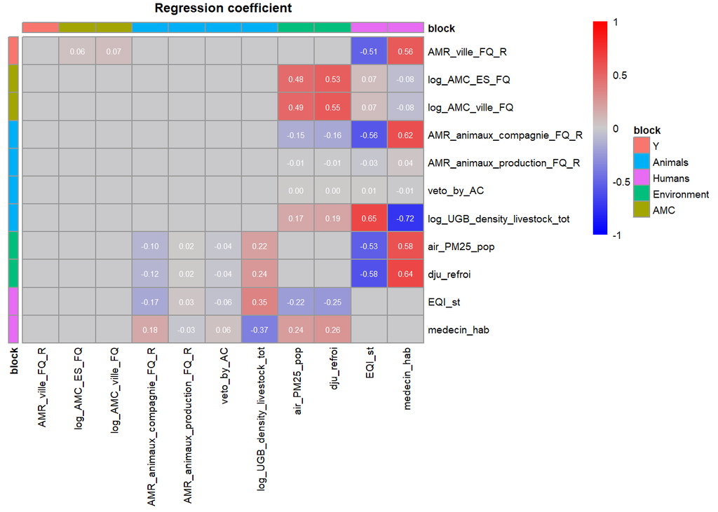

```r
Matrix_reg <- function(model_type){

beta <- paths %>% dplyr::filter(model == model_type) %>%
  dplyr::select(term, estimate)
w <- weights %>% dplyr::filter(model == model_type) %>%
  dplyr::select(term, estimate, block)
p <- loadings %>% dplyr::filter(model == model_type) %>%
  dplyr::select(term, estimate, block)

nrow(beta)
nrow(p)
nrow(w)

M <- matrix(rep(0, length(p$term)^2), nrow = length(p$term), ncol = length(p$term))
rownames(M) <- p$term
colnames(M) <- p$term

for (bl in levels(factor(p$block))){
  idx <- which(stringr::str_remove(beta$term, "~.*") == bl)
  beta_chosen <- beta[idx,]
  w_choosen <- w[which(w$block %in% str_remove(beta[idx,]$term, ".*~")),]

  beta_chosen$block <- str_remove(beta_chosen$term, ".*~")

  # loadings du bloc CIBLE (fixes pour tout bl, ne dépendent pas de b)
  p_bl <- p[p$block == bl,]
  is <- which(rownames(M) %in% p_bl$term)
  pp <- p_bl$estimate   # même ordre que rownames(M)[is]

  for (b in beta_chosen$block){
    js <- which(colnames(M) %in% w_choosen[w_choosen$block == b,]$term)
    ww <- w_choosen[w_choosen$block == b,]$estimate
    bb <- beta_chosen[beta_chosen$block == b,]$estimate

    M[is, js] <- bb * pp %*% t(ww)
  }
}

return(M)}

M <- Matrix_reg(model_type = "int")

cl <- as.data.frame(correspondance_block[which(correspondance_block$term %in% colnames(M)),])
cl <- rbind.data.frame(cl,
data.frame(block = "Y", term = "AMR_ville_FQ_R"))
rownames(cl) <- cl$term
cl <- cl %>% dplyr::select(-term)

disp <- matrix(sprintf("%.2f", M), nrow = nrow(M), ncol = ncol(M))
disp[abs(M) == 0] <- ""

ann_colors <- list(
 block = c(
    Y = "#F8766D",
    Animals = "#00B0F6",
    Humans = "#E76BF3",
    Environment = "#00BF7D",
    AMC = "#A3A500"
  )
)

pheatmap::pheatmap(M,
                          color = colorRampPalette(c("blue", "grey80", "red"))(100),
                          breaks = seq(-1, 1, length.out = 101),
                          cluster_rows = FALSE,
                          cluster_cols = FALSE,
                          # clustering_distance_rows = "euclidean",
                          # clustering_distance_cols = "euclidean",
                          # clustering_method = "ward.D2",
                          number_format = "%.1f",
                          fontsize = 7,
                          number_color = "white",
                          legend = TRUE,
                          legend_breaks = c(-1, -0.5, 0, 0.5, 1),
                          legend_labels = c("-1", "-0.5", "0", "0.5", "1"),
                          angle_col = 90,
                          annotation_row = cl,
                          annotation_col = cl,
                          annotation_colors = ann_colors,
                          display_numbers = disp,
                          main = "Regression coefficient")
```

### 3.1.10 Regression Ridge VL

```r
submodels <- c("Y ~ AMC + Humans",
  "AMC ~ Humans + Environment",
  "Environment ~ Animals + Humans",
  "Humans ~ Environment + Animals",
  "Animals ~ Environment + Humans")

tab_ridge <- sum_gsca_int$paths %>%
  dplyr::select(term, path_coeff = estimate) %>%
  dplyr::arrange(desc(term))

get_ridge_betas <- function(formula_str, data) {
  parts <- strsplit(formula_str, "~")[[1]]
  response <- trimws(parts[1])
  predictors <- trimws(strsplit(parts[2], "\\+")[[1]])

  x <- as.matrix(data[, predictors, drop = FALSE])
  y <- data[,response]

  set.seed(123)
  cv_ridge <- cv.glmnet(x, y, alpha = 0)
  best_lambda <- cv_ridge$lambda.min
  out.ridge <- glmnet(x, y, alpha = 0, lambda = best_lambda)

  betas <- as.matrix(out.ridge$beta)

  data.frame(
    term = paste0(response, "~", predictors),
    ridge_beta = as.numeric(betas),
    stringsAsFactors = FALSE
  )
}

# Application à tous les submodels + assemblage
ridge_results <- purrr::map_dfr(submodels, get_ridge_betas, data = latent_coord)

# Jointure avec ton tableau initial
tab_ridge <- tab_ridge %>%
  dplyr::left_join(ridge_results, by = "term")

knitr::kable(tab_ridge, digits = 2)
```

| term | path_coeff | ridge_beta |
| --- | --- | --- |
| Y~Humans | 0.84 | 0.75 |
| Y~AMC | 0.12 | 0.16 |
| Humans~Environment | 0.44 | 0.44 |
| Humans~Animals | 0.58 | 0.54 |
| Environment~Humans | 1.28 | 0.78 |
| Environment~Animals | -0.41 | 0.06 |
| Animals~Humans | 1.19 | 0.81 |
| Animals~Environment | -0.29 | 0.05 |
| AMC~Humans | -0.13 | 0.19 |
| AMC~Environment | 0.80 | 0.32 |

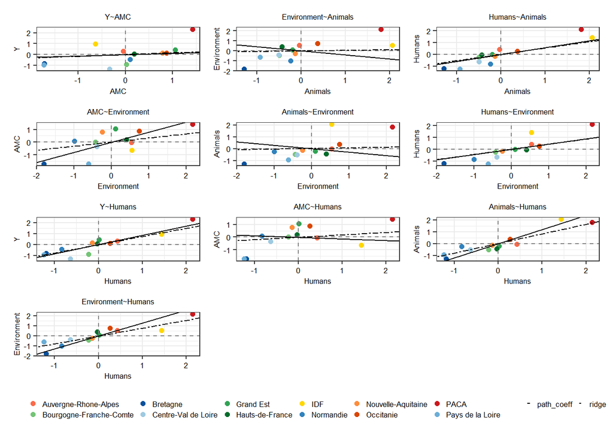

```r
# scatterplot VL avec les betas normaux et ridge
make_scatter2 <- function(term, tab_ridge) {
  vars <- str_split(term, "~")[[1]]
  yvar <- vars[1]
  xvar <- vars[2]
  form <- paste0(yvar, "~", xvar)

  ggplot(df_coord, aes(x = .data[[xvar]], y = .data[[yvar]], col = id)) +
    geom_point(size = 1.6) +
    theme_bw() +
    geom_hline(yintercept = 0, col = "grey50", linetype = "dashed") +
    geom_vline(xintercept = 0, col = "grey50", linetype = "dashed") +
    geom_abline(aes(intercept = 0, slope = tab_ridge[tab_ridge$term == form, "path_coeff"],
                     linetype = "path_coeff"),
                color = "black", key_glyph = "path") +
    geom_abline(aes(intercept = 0, slope = tab_ridge[tab_ridge$term == form, "ridge_beta"],
                     linetype = "ridge"),
                color = "black", key_glyph = "path") +
    scale_linetype_manual(name = NULL,
                           values = c("path_coeff" = "solid", "ridge" = "twodash")) +
    theme(legend.title = element_blank(),
          axis.text = element_text(color = "black", size = 6.5),
          axis.title = element_text(size = 6.5),
          legend.text = element_text(size = 6.5),
          plot.title = element_text(hjust = 0.5, size = 6.5),
        legend.position = "bottom",
        legend.spacing = unit(0.5, "cm"),
        legend.key.height = unit(0.1, "cm"),
        legend.key.width = unit(0.1, "cm"),
        legend.key.spacing.y = unit(0.1, "cm")) +
    scale_color_manual(values = cols) +
    labs(title = term, x = xvar, y = yvar)
}

# Appliquer à tous les liens
plot_list <- map(terms, make_scatter2, tab_ridge = tab_ridge) %>%
  set_names(terms)

wrap_plots(plot_list, ncol = 3) +
  plot_layout(guides = "collect") &
  theme(legend.position = "bottom") &
  guides(col = guide_legend(nrow = 2, override.aes = list(size = 1.6)))
```

## 3.2 AMR_EHPAD_FQ_R

Tous les paths coeffs semblent assez différents de 0 donc on ne considère pas de modèle intermédiaire ici, que le modèle simple et le modèle complet.

### 3.2.1 Unidimensionalité des blocks

On peut supposer que le block AMC est unidimensionnel.

```r
dfPC1.AMR_EHPAD_FQ <- scale(dfPC1.AMR_EHPAD_FQ) # standardisation

# Hypothèse d'unidimensionalité des blocks
Xnorm.block <- list(dfPC1.AMR_EHPAD_FQ[,which(colnames(dfPC1.AMR_EHPAD_FQ) %in% c("log_AMC_EHPAD_FQ", "log_AMC_ES_totale", "log_AMC_ville_totale"))],
                    dfPC1.AMR_EHPAD_FQ[,which(colnames(dfPC1.AMR_EHPAD_FQ) %in% c("AMR_animaux_production_FQ_R", "veto_by_AC", "tx_possession_chats", "log_UGB_density_livestock_tot"))],
                    dfPC1.AMR_EHPAD_FQ[,which(colnames(dfPC1.AMR_EHPAD_FQ) %in% c("air_PM25_pop", "dju_refroi"))],
                    dfPC1.AMR_EHPAD_FQ[,which(colnames(dfPC1.AMR_EHPAD_FQ) %in% c("medecin_hab", "pop_75_plus_prop"))]
                    )

nb.block <- length(Xnorm.block)
order_blocks <- c("AMC", "Animals", "Environment", "Humans")
eigen <- lapply(1:nb.block, function(k) FactoMineR::PCA(Xnorm.block[[k]], scale.unit = TRUE, ncp = 2, graph = F)$eig)
perc_var_comp1 <- c()
for(i in 1:nb.block){
  perc_var_comp1 <- c(perc_var_comp1, eigen[[i]][1,2])
}
df.unim <- data.frame(order_blocks,
                      percentage_variance_PCA_comp1 = round(perc_var_comp1, 2))
knitr::kable(df.unim)
```

| order_blocks | percentage_variance_PCA_comp1 |
| --- | --- |
| AMC | 71.71 |
| Animals | 47.17 |
| Environment | 52.24 |
| Humans | 50.54 |

### 3.2.2 Paths coeffs

On ne peut comparer les deux modèles que sur les modèles qui concernent Y comme variable réponse. A part pour AMC les paths coeffs sont différents. Mais les intervalles de confiance sont plus petits pour le modèle simple.

```r
model_simple <- paste(
  paste("Y =~", colnames(dfPC1.AMR_EHPAD_FQ)[1]),
  "AMC =~ log_AMC_EHPAD_FQ + log_AMC_ES_totale +   log_AMC_ville_totale",
  "Animals =~ AMR_animaux_production_FQ_R + veto_by_AC + tx_possession_chats + log_UGB_density_livestock_tot",
  "Environment =~ dju_refroi + air_PM25_pop",
  "Humans =~ medecin_hab + pop_75_plus_prop",
  "Y ~ AMC + Animals + Environment + Humans",
  sep = "\n\t\t"
)

model_complet <- paste(
  paste("Y =~", colnames(dfPC1.AMR_EHPAD_FQ)[1]),
  "AMC =~ log_AMC_EHPAD_FQ + log_AMC_ES_totale +   log_AMC_ville_totale",
  "Animals =~ AMR_animaux_production_FQ_R + veto_by_AC + tx_possession_chats + log_UGB_density_livestock_tot",
  "Environment =~ dju_refroi + air_PM25_pop",
  "Humans =~ medecin_hab + pop_75_plus_prop",
  "Y ~ AMC + Animals + Environment + Humans",
  "AMC ~ Humans + Environment",
  "Environment ~ Animals + Humans",
  "Humans ~ Environment + Animals",
  "Animals ~ Environment + Humans",
  sep = "\n\t\t"
)


set.seed(123)
mod_complet <- gesca::gesca.run(model_complet, dfPC1.AMR_EHPAD_FQ, nbt = 100)
sum_gsca_complet <- summary_gesca2(mod_complet)
mod_simple <- gesca::gesca.run(model_simple, dfPC1.AMR_EHPAD_FQ, nbt = 100)
sum_gsca_simple <- summary_gesca2(mod_simple)

paths_complet <- sum_gsca_complet$paths
paths_complet$model <- rep("complet", nrow(paths_complet))
paths_simple <- sum_gsca_simple$paths
paths_simple$model <- rep("simple", nrow(paths_simple))
paths <- rbind.data.frame(paths_complet, paths_simple)

DT::datatable(paths)
```

|  | group | term | estimate | std.error | ci_lb | ci_ub | model |
| --- | --- | --- | --- | --- | --- | --- | --- |
| 1 | all | Y~AMC | 0.1562 | 5.007 | -4.4731 | 8.5818 | complet |
| 2 | all | Y~Animals | 0.7829 | 16.3815 | -27.1188 | 33.958 | complet |
| 3 | all | Environment~Animals | -1.6376 | 1.3464 | -1.932 | 4.5972 | complet |
| 4 | all | Humans~Animals | 1.1192 | 1.1103 | -2.1551 | 2.2122 | complet |
| 5 | all | Y~Environment | 1.1137 | 10.9706 | -17.7856 | 27.2983 | complet |
| 6 | all | AMC~Environment | 0.6264 | 1.2014 | -2.4296 | 1.8248 | complet |
| 7 | all | Animals~Environment | -0.4415 | 1.1971 | -2.0982 | 2.0966 | complet |
| 8 | all | Humans~Environment | 0.4806 | 1.0873 | -1.551 | 2.878 | complet |
| 9 | all | Y~Humans | -0.6725 | 11.0414 | -26.1157 | 26.8172 | complet |
| 10 | all | AMC~Humans | 0.1136 | 1.0931 | -2.1989 | 2.6022 | complet |

[output cut: 6 more lines]

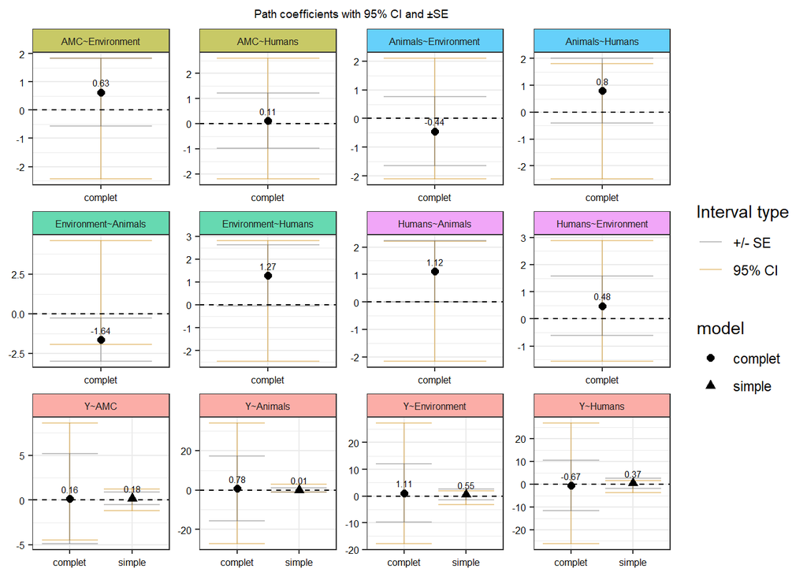

```r
# 1. extraire la variable à expliquer (à gauche du ~)
paths$outcome <- str_remove(paths$term, "~.*")

# 2. créer une palette nommée par variable à expliquer
outcomes <- unique(paths$outcome)
pal <- setNames(c("#F8766D", "#00BF7D", "#E76BF3",
                  "#A3A500", "#00B0F6"), outcomes)

# 3. vecteur de couleurs DANS L'ORDRE DES FACETTES
# (l'ordre des term tel qu'il apparaîtra dans facet_wrap, généralement alphabétique
# sauf si term est déjà un factor avec un ordre précis)
term_outcome_map <- setNames(paths$outcome, paths$term)
term_levels <- sort(unique(paths$term))
# applique 0.6 d'opacité à chaque couleur de la palette
pal_alpha <- scales::alpha(pal, 0.6)
strip_colors <- pal_alpha[term_outcome_map[term_levels]]



ggplot(paths, aes(x = model, y = estimate)) +
    geom_errorbar(aes(ymin = ci_lb, ymax = ci_ub, color = "95% CI"),
                   height = 0.1, alpha = 0.4) +
    geom_errorbar(aes(ymin = estimate - std.error,
                       ymax = estimate + std.error,
                       color = "+/- SE"),
                   height = 0.1, linewidth = 0.4, alpha = 0.4) +
    geom_point(aes(shape = model), size = 2) +
    geom_text(aes(label = round(estimate, 2)), size = 2,
              vjust = -0.86)+
    geom_hline(yintercept = 0, linetype = "dashed") +
  ggh4x::facet_wrap2(~ term, scales = "free",
                       strip = strip_themed(
      background_x = elem_list_rect(fill = strip_colors)
    ))+
    theme_bw() +
    labs(title = "Path coefficients with 95% CI and ±SE")+
    theme(axis.text = element_text(color = "black", size = 6),
          axis.title = element_blank(),
          plot.title = element_text(hjust = 0.5, size = 7),
          strip.text = element_text(size = 6))+
  scale_color_manual(name = "Interval type",
                     values = c(
                       "95% CI" = "orange3",
                       "+/- SE" = "grey40"))
```

### 3.2.3 Loadings

Les variables des blocks Environnement et AMC sont stables en termes de loadings. Mais pas celles des blocks Humans et Animals, le modèle simple sous-estime ou sur-estime les loadings à chaque fois pour ces variables là, par rapport au modèle complet.

```r
loadings_complet <- sum_gsca_complet$loadings
loadings_complet$model <- rep("complet", nrow(loadings_complet))
loadings_simple <- sum_gsca_simple$loadings
loadings_simple$model <- rep("simple", nrow(loadings_simple))
loadings <- rbind.data.frame(loadings_complet, loadings_simple)

DT::datatable(loadings)
```

|  | group | term | estimate | std.error | ci_lb | ci_ub | model |
| --- | --- | --- | --- | --- | --- | --- | --- |
| 1 | all | AMR_EHPAD_FQ_R | 1 | 0 | 1 | 1 | complet |
| 2 | all | log_AMC_EHPAD_FQ | 0.8623 | 0.3683 | -0.7338 | 0.9659 | complet |
| 3 | all | log_AMC_ES_totale | 0.7717 | 0.3991 | -0.8791 | 0.9508 | complet |
| 4 | all | log_AMC_ville_totale | 0.895 | 0.298 | -0.2323 | 0.9851 | complet |
| 5 | all | AMR_animaux_production_FQ_R | 0.1891 | 0.609 | -0.9328 | 0.9299 | complet |
| 6 | all | veto_by_AC | 0.3783 | 0.6189 | -0.9157 | 0.9369 | complet |
| 7 | all | tx_possession_chats | 0.5325 | 0.7074 | -0.9424 | 0.9477 | complet |
| 8 | all | log_UGB_density_livestock_tot | 0.5581 | 0.6632 | -0.911 | 0.9831 | complet |
| 9 | all | air_PM25_pop | 0.7845 | 0.7842 | -0.9994 | 0.9877 | complet |
| 10 | all | dju_refroi | 0.6546 | 0.7267 | -0.9778 | 0.9493 | complet |

[output cut: 14 more lines]

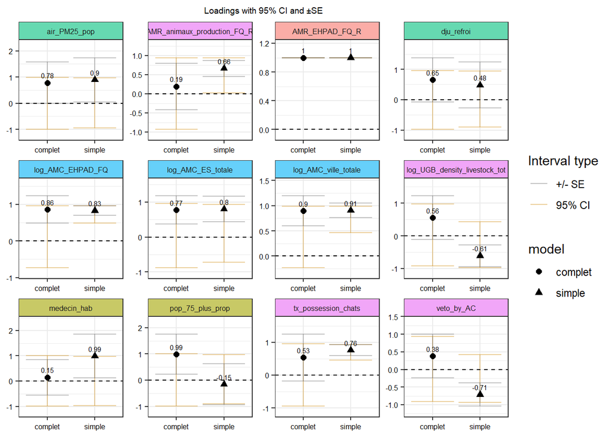

```r
loadings <- loadings %>% dplyr::left_join(correspondance_block,
                              by = "term")
loadings$block <- ifelse(is.na(loadings$block),
                         "Y", loadings$block)

blocks <- unique(loadings$block)
pal <- setNames(c("#F8766D", "#00B0F6", "#E76BF3",
                  "#00BF7D", "#A3A500"), blocks)
term_loadings_map <- setNames(loadings$block, loadings$term)
term_levels <- sort(unique(loadings$term))
# applique 0.6 d'opacité à chaque couleur de la palette
pal_alpha <- scales::alpha(pal, 0.6)
strip_colors <- pal_alpha[term_loadings_map[term_levels]]


ggplot(loadings, aes(x = model, y = estimate)) +
    geom_errorbar(aes(ymin = ci_lb, ymax = ci_ub, color = "95% CI"), height = 0.1, alpha = 0.4) +
    geom_errorbar(aes(ymin = estimate - std.error,
                       ymax = estimate + std.error,
                       color = "+/- SE"),
                   height = 0.1, linewidth = 0.4, alpha = 0.4) +
    geom_point(aes(shape = model), size = 2) +
    geom_text(aes(label = round(estimate, 2)), size = 2,     vjust = -0.86)+
    geom_hline(yintercept = 0, linetype = "dashed") +
    ggh4x::facet_wrap2(~ term, scales = "free",
                       strip = strip_themed(
      background_x = elem_list_rect(fill = strip_colors)
    ))+
    theme_bw() +
    scale_y_continuous(expand = expansion(mult = c(0.15, 0.25))) +
    labs(title = "Loadings with 95% CI and ±SE")+
    theme(axis.text = element_text(color = "black", size = 6),
          axis.title = element_blank(),
          plot.title = element_text(hjust = 0.5, size = 7),
          strip.text = element_text(size = 6))+
  scale_color_manual(name = "Interval type",
                     values = c(
                       "95% CI" = "orange3",
                       "+/- SE" = "grey40"))
```

### 3.2.4 Poids

- Dans le block “Animals” Le modèle simple donne plus d’importance à la résisantance aux FQ chez les animaux de production, le modèle complet en donne moins à cette variable là et plus aux autres variables.
- Le modèle simple donne moins d’importance au vieillissement de la population et plus d’importance aux nombre de médecins par habitants.
- Pour l’instant, on peut dire que ce sont surtout les blocks Animals et Humans qui différencient les deux modèles.

```r
weights_complet <- sum_gsca_complet$weights
weights_complet$model <- rep("complet", nrow(weights_complet))
weights_simple <- sum_gsca_simple$weights
weights_simple$model <- rep("simple", nrow(weights_simple))
weights <- rbind.data.frame(weights_complet, weights_simple)

DT::datatable(weights)
```

|  | group | term | estimate | std.error | ci_lb | ci_ub | model |
| --- | --- | --- | --- | --- | --- | --- | --- |
| 1 | all | AMR_EHPAD_FQ_R | 1 | 0 | 1 | 1 | complet |
| 2 | all | log_AMC_EHPAD_FQ | 0.4652 | 0.2455 | -0.4496 | 0.6844 | complet |
| 3 | all | log_AMC_ES_totale | 0.3042 | 0.2587 | -0.5852 | 0.5946 | complet |
| 4 | all | log_AMC_ville_totale | 0.4068 | 0.1964 | -0.0977 | 0.7656 | complet |
| 5 | all | AMR_animaux_production_FQ_R | 0.0559 | 0.3418 | -0.662 | 0.6989 | complet |
| 6 | all | veto_by_AC | 0.4522 | 0.3808 | -0.6736 | 0.8249 | complet |
| 7 | all | tx_possession_chats | 0.8455 | 0.4484 | -0.6995 | 0.8315 | complet |
| 8 | all | log_UGB_density_livestock_tot | 0.6596 | 0.5325 | -0.7235 | 0.9772 | complet |
| 9 | all | air_PM25_pop | 0.7561 | 0.6923 | -1.0197 | 0.9649 | complet |
| 10 | all | dju_refroi | 0.6215 | 0.5968 | -0.9583 | 0.9003 | complet |

[output cut: 14 more lines]

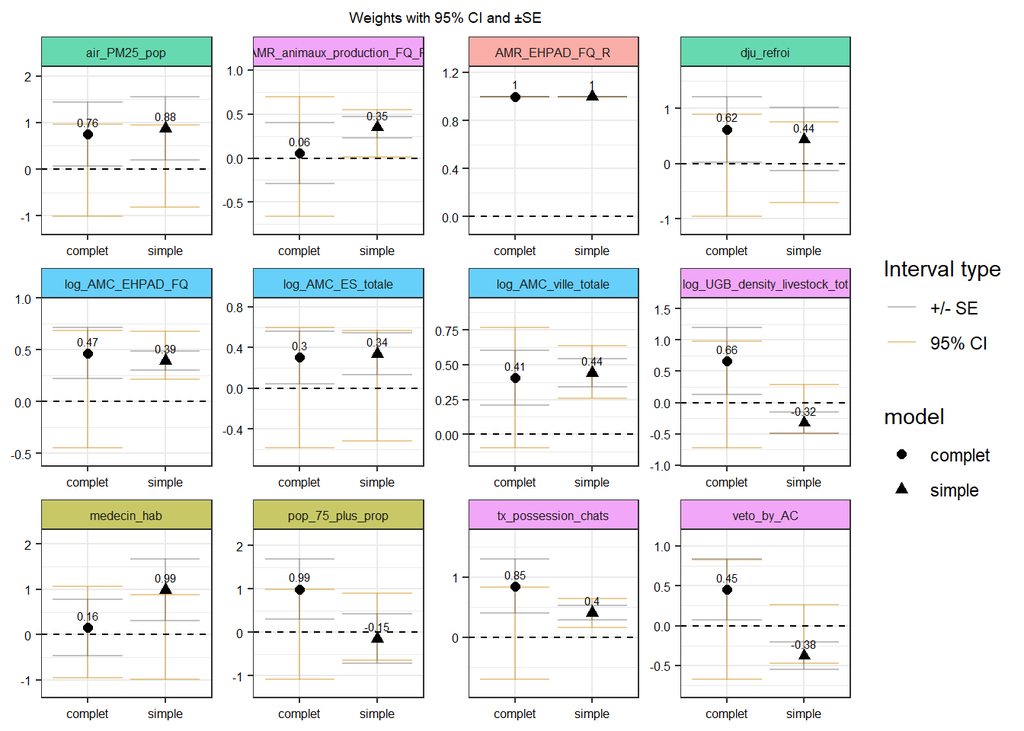

```r
weights <- weights %>% dplyr::left_join(correspondance_block,
                              by = "term")
weights$block <- ifelse(is.na(weights$block),
                         "Y", weights$block)

blocks <- unique(weights$block)
pal <- setNames(c("#F8766D", "#00B0F6", "#E76BF3",
                  "#00BF7D", "#A3A500"), blocks)
term_weights_map <- setNames(weights$block, weights$term)
term_levels <- sort(unique(weights$term))
# applique 0.6 d'opacité à chaque couleur de la palette
pal_alpha <- scales::alpha(pal, 0.6)
strip_colors <- pal_alpha[term_loadings_map[term_levels]]


ggplot(weights, aes(x = model, y = estimate)) +
    geom_errorbar(aes(ymin = ci_lb, ymax = ci_ub, color = "95% CI"),
                   height = 0.1, alpha = 0.4) +
    geom_errorbar(aes(ymin = estimate - std.error,
                       ymax = estimate + std.error,
                       color = "+/- SE"),
                   height = 0.1, linewidth = 0.4, alpha = 0.4) +
    geom_point(aes(shape = model), size = 2) +
    geom_text(aes(label = round(estimate, 2)),
              size = 2, vjust = -0.86)+
    geom_hline(yintercept = 0, linetype = "dashed") +
    ggh4x::facet_wrap2(~ term, scales = "free",
                       strip = strip_themed(
      background_x = elem_list_rect(fill =   strip_colors)))+
  scale_y_continuous(expand = expansion(mult = c(0.15, 0.25))) +
    theme_bw() +
    labs(title = "Weights with 95% CI and ±SE")+
    theme(axis.text = element_text(color = "black", size = 6),
          axis.title = element_blank(),
          plot.title = element_text(hjust = 0.5, size = 7),
          strip.text = element_text(size = 6))+
  scale_color_manual(name = "Interval type",
                     values = c(
                       "95% CI" = "orange3",
                       "+/- SE" = "grey40"))
```

### 3.2.5 R2

Forcément, on ne peut comparer que le Y et il a l’air un peu meilleur avec le modèle simple.

```r
# corrélations entre composantes latentes
# complet
latentcorr_complet <- mod_complet$latentcorr
rownames(latentcorr_complet) <- c("Y", "AMC", "Animals", "Environment", "Humans")
colnames(latentcorr_complet) <- c("Y", "AMC", "Animals", "Environment", "Humans")
# simple
latentcorr_simple <- mod_simple$latentcorr
rownames(latentcorr_simple) <- c("Y", "AMC", "Animals", "Environment", "Humans")
colnames(latentcorr_simple) <- c("Y", "AMC", "Animals", "Environment", "Humans")

R2 <- data.frame(term = sum_gsca_complet$paths$term,
                 R2_model_complet = rep(NA, length(sum_gsca_complet$paths$term)),
                 R2_model_simple = rep(NA, length(sum_gsca_complet$paths$term)))

for (i in 1:nrow(R2)){
  # complet
  beta_comp_block <- sum_gsca_complet$paths$estimate[sum_gsca_complet$paths$term == R2$term[i]]
r_block_comp <- latentcorr_complet[stringr::str_split(R2$term[i], "~")[[1]][1], stringr::str_split(R2$term[i], "~")[[1]][2]]
R2[i,]$R2_model_complet <- beta_comp_block * r_block_comp
# simple
if (R2$term[i] %in% sum_gsca_simple$paths$term){
beta_simple_block <- sum_gsca_simple$paths$estimate[sum_gsca_simple$paths$term == R2$term[i]]
r_block_simple <- latentcorr_simple[stringr::str_split(R2$term[i], "~")[[1]][1], stringr::str_split(R2$term[i], "~")[[1]][2]]
R2[i,]$R2_model_simple <- beta_simple_block * r_block_simple}
else {R2[i,]$R2_model_simple <- NA}
}

knitr::kable(R2, digits = 2)
```

| term | R2_model_complet | R2_model_simple |
| --- | --- | --- |
| Y~AMC | 0.10 | 0.12 |
| Y~Animals | -0.34 | 0.00 |
| Environment~Animals | 0.89 | NA |
| Humans~Animals | 0.96 | NA |
| Y~Environment | 0.97 | 0.47 |
| AMC~Environment | 0.38 | NA |
| Animals~Environment | 0.24 | NA |
| Humans~Environment | -0.06 | NA |
| Y~Humans | 0.09 | 0.27 |
| AMC~Humans | 0.00 | NA |
| Animals~Humans | 0.69 | NA |
| Environment~Humans | -0.16 | NA |

```r
# Les R2 par blocs
r2 <- data.frame(
  var = c("Y", "AMC", "Animals", "Environment", "Humans"),
  R2_model_complet = round(mod_complet$R2[1,], 2),
  R2_model_simple = round(mod_simple$R2[1,], 2)
)

knitr::kable(r2)
```

| var | R2_model_complet | R2_model_simple |
| --- | --- | --- |
| Y | 0.83 | 0.87 |
| AMC | 0.39 | 0.00 |
| Animals | 0.93 | 0.00 |
| Environment | 0.73 | 0.00 |
| Humans | 0.90 | 0.00 |

### 3.2.6 FIT

```r
fit_complet <- featmeasures2(mod_complet)
```

```
##   Number of parameters        36
##   Number of bootstrap samples 100
##
##  Measure Estimate    Std.Error         CI_LB   CI_UB
##      FIT   0.5720       0.0481        0.5817  0.7569
##     AFIT   0.4293       0.0641        0.4423  0.6759
##      GFI -37.7900 1942443.0225 -3337645.2368 -1.2377
##     SRMR   0.5441       0.1160        0.3328  0.7539
##    FIT_M   0.4962       0.0665        0.4787  0.7224
##    FIT_S   0.7537       0.1063        0.5637  0.9746
```

```r
fit_complet$model <- rep("complet", nrow(fit_complet))
fit_simple <- featmeasures2(mod_simple)
```

```
##   Number of parameters        28
##   Number of bootstrap samples 100
##
##  Measure Estimate Std.Error     CI_LB  CI_UB
##      FIT   0.4674    0.0463    0.4256 0.5942
##     AFIT   0.3389    0.0575    0.2869 0.4962
##      GFI   0.9728 2825.3786 -117.0070 0.9900
##     SRMR   0.3174    0.0446    0.3054 0.4794
##    FIT_M   0.5897    0.0662    0.5251 0.7700
##    FIT_S   0.1741    0.0118    0.1600 0.1998
```

```r
fit_simple$model <- rep("simple", nrow(fit_simple))
fit <- rbind.data.frame(fit_complet, fit_simple)

DT::datatable(fit)
```

|  | Measure | Estimate | Std.Error | CI_LB | CI_UB | model |
| --- | --- | --- | --- | --- | --- | --- |
| 1 | FIT | 0.572 | 0.0481 | 0.5817 | 0.7569 | complet |
| 2 | AFIT | 0.4293 | 0.0641 | 0.4423 | 0.6759 | complet |
| 3 | GFI | -37.79 | 1942443.0225 | -3337645.2368 | -1.2377 | complet |
| 4 | SRMR | 0.5441 | 0.116 | 0.3328 | 0.7539 | complet |
| 5 | FIT_M | 0.4962 | 0.0665 | 0.4787 | 0.7224 | complet |
| 6 | FIT_S | 0.7537 | 0.1063 | 0.5637 | 0.9746 | complet |
| 7 | FIT | 0.4674 | 0.0463 | 0.4256 | 0.5942 | simple |
| 8 | AFIT | 0.3389 | 0.0575 | 0.2869 | 0.4962 | simple |
| 9 | GFI | 0.9728 | 2825.3786 | -117.007 | 0.99 | simple |
| 10 | SRMR | 0.3174 | 0.0446 | 0.3054 | 0.4794 | simple |

[output cut: 2 more lines]

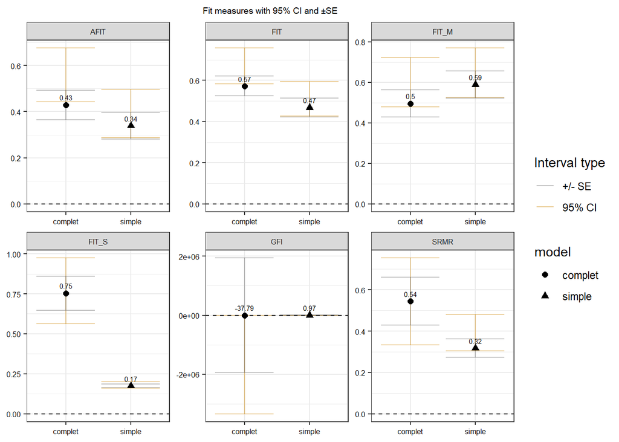

```r
ggplot(fit, aes(x = model, y = Estimate)) +
    geom_errorbar(aes(ymin = CI_LB, ymax = CI_UB, color = "95% CI"),
                   height = 0.1, alpha = 0.4) +
    geom_errorbar(aes(ymin = Estimate - Std.Error,
                       ymax = Estimate + Std.Error,
                       color = "+/- SE"),
                   height = 0.1, linewidth = 0.4, alpha = 0.4) +
    geom_point(aes(shape = model), size = 2) +
    geom_text(aes(label = round(Estimate, 2)), vjust = -0.86, size = 2)+
    geom_hline(yintercept = 0, linetype = "dashed") +
    facet_wrap(~ Measure, scales = "free")+
    theme_bw() +
    labs(title = "Fit measures with 95% CI and ±SE")+
    theme(axis.text = element_text(color = "black", size = 6),
          axis.title = element_blank(),
          plot.title = element_text(hjust = 0.5, size = 7),
          strip.text = element_text(size = 6))+
  scale_color_manual(name = "Interval type",
                     values = c(
                       "95% CI" = "orange3",
                       "+/- SE" = "grey40"))
```

### 3.2.7 scatterplot VL

```r
# str(mod_complet$WR)
# str(mod_complet$MatW)
#
# sum_gsca_complet$weights

dimnames(mod_complet$WR)
```

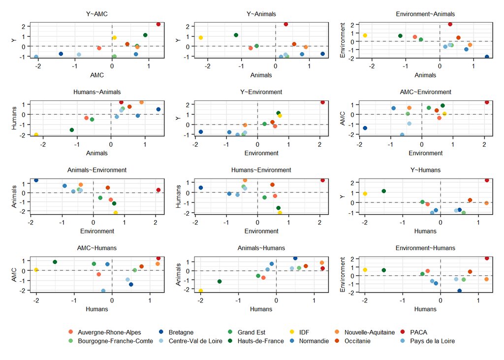

```r
rownames(mod_complet$WR) <- sum_gsca_complet$weights$term
colnames(mod_complet$WR) <- c("Y", "AMC", "Animals",
                          "Environment", "Humans")

indicateur <- rownames(mod_complet$WR)
X <- scale(dfPC1.AMR_EHPAD_FQ[, indicateur])
latent_coord <- X %*% mod_complet$WR

# 1. Transformer la matrice en data frame avec une colonne "id" pour la couleur
df_coord <- as.data.frame(latent_coord) %>%
  rownames_to_column("id")

# 2. Récupérer les termes
terms <- sum_gsca_complet$paths$term

plot_list <- map(terms, make_scatter) %>%
  set_names(terms)

wrap_plots(plot_list, ncol = 3) +
  plot_layout(guides = "collect") &
  theme(legend.position = "bottom") &
  guides(col = guide_legend(nrow = 2, override.aes = list(size = 1.6)))
```

```r
# ggsave("C:/Users/g.martet/Documents/functional_study/figures diapo/scatterplot_VL_AMR_EHPAD_FQ.png", width = 7, height = 7)
```

### 3.2.8 graphes

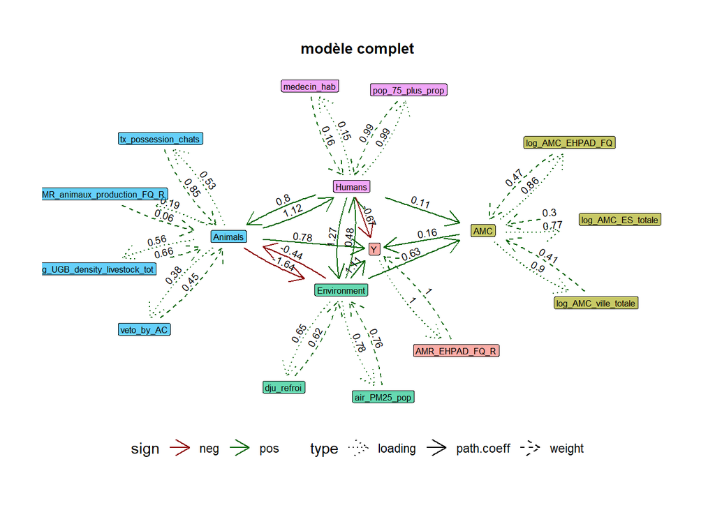

```r
#-----------------------
# construire le dataset
#-----------------------

# les paths
paths$from <- str_remove(paths$term, ".*~")
paths2 <- paths %>%
  dplyr::rename(to = "outcome") %>%
  dplyr::select(from, to, estimate, model) %>%
  dplyr::mutate(sign = ifelse(estimate >=0, "pos", "neg")) %>%
  dplyr::mutate(block = from) %>%
  dplyr::mutate(type = "path.coeff")
# les weights
weights2 <- weights %>%
  dplyr::rename(from = "term", to = "block") %>%
  dplyr::select(from, to, estimate, model) %>%
  dplyr::mutate(sign = ifelse(estimate >=0, "pos", "neg")) %>%
  dplyr::mutate(block = to) %>%
  dplyr::mutate(type = "weight")
# les loadings
loadings2 <- loadings %>%
  dplyr::rename(from = "block", to = "term") %>%
  dplyr::select(from, to, estimate, model) %>%
  dplyr::mutate(sign = ifelse(estimate >=0, "pos", "neg")) %>%
  dplyr::mutate(block = from) %>%
  dplyr::mutate(type = "loading")

dat_graph <- rbind(paths2, weights2, loadings2)

#----------------------
# modèle complet
#----------------------

dat_filtered <- dat_graph %>%
  dplyr::filter(model == "complet")

# Construire le tableau des noeuds avec leur block
nodes_df <- dplyr::bind_rows(
  dat_filtered %>% dplyr::select(name = from, block),
  dat_filtered %>% dplyr::select(name = to, block)
) %>%
  dplyr::filter(!is.na(block)) %>%   # garde les lignes où block est renseigné
  dplyr::distinct(name, .keep_all = TRUE)  # une ligne par noeud

# Construire le graphe explicitement
graph <- tbl_graph(
  nodes = nodes_df,
  edges = dat_filtered %>% dplyr::select(from, to, estimate, sign, type),
  node_key = "name"
)

g1 <- ggraph(graph) +
  geom_edge_fan(aes(colour = sign,
                     end_cap = label_rect(node2.name),
                     start_cap = label_rect(node1.name),
                    label = round(estimate, 2),
                    linetype = type),
                arrow = arrow(length = unit(4, 'mm')),
                label_dodge = unit(1.8, 'mm'),
                angle_calc = "along",
                label_size = 2.5) +
  geom_node_label(aes(label = name, fill = block), size = 2.2,
                  show.legend = FALSE, alpha = 0.6) +
  labs(title = "modèle complet")+
  scale_x_continuous(expand = expansion(mult = 0.10)) +
  ggraph::theme_graph(background = 'white') +
  theme(legend.position = "bottom") +
  theme(plot.title = element_text(hjust = 0.5, size = 10))+
  scale_edge_colour_manual(values = c("darkred", "darkgreen"))+
  scale_edge_linetype_manual(values = c(path.coeff = "solid", weight = "dashed", loading = "dotted"))+
  scale_fill_manual(values = c(Y = "#F8766D", Animals = "#00B0F6", Humans = "#E76BF3",
                  Environment = "#00BF7D", AMC = "#A3A500"))


#----------------------
# modèle simple
#----------------------

dat_filtered <- dat_graph %>%
  dplyr::filter(model == "simple")

# Construire le tableau des noeuds avec leur block
nodes_df <- dplyr::bind_rows(
  dat_filtered %>% dplyr::select(name = from, block),
  dat_filtered %>% dplyr::select(name = to, block)
) %>%
  dplyr::filter(!is.na(block)) %>%   # garde les lignes où block est renseigné
  dplyr::distinct(name, .keep_all = TRUE)  # une ligne par noeud

# Construire le graphe explicitement
graph <- tbl_graph(
  nodes = nodes_df,
  edges = dat_filtered %>% dplyr::select(from, to, estimate, sign, type),
  node_key = "name"
)

g2 <- ggraph(graph) +
  geom_edge_fan(aes(colour = sign,
                     end_cap = label_rect(node2.name),
                     start_cap = label_rect(node1.name),
                    label = round(estimate, 2),
                    linetype = type),
                arrow = arrow(length = unit(4, 'mm')),
                label_dodge = unit(1.8, 'mm'),
                angle_calc = "along",
                label_size = 2.5) +
  geom_node_label(aes(label = name, fill = block), size = 2.2,
                  show.legend = FALSE, alpha = 0.6) +
  labs(title = "modèle simple")+
  scale_x_continuous(expand = expansion(mult = 0.10)) +
  ggraph::theme_graph(background = 'white') +
  theme(legend.position = "bottom") +
  theme(plot.title = element_text(hjust = 0.5, size = 10))+
  scale_edge_colour_manual(values = c("darkred", "darkgreen"))+
  scale_edge_linetype_manual(values = c(path.coeff = "solid", weight = "dashed", loading = "dotted"))+
  scale_fill_manual(values = c(Y = "#F8766D", Animals = "#00B0F6", Humans = "#E76BF3",
                  Environment = "#00BF7D", AMC = "#A3A500"))

g1
```

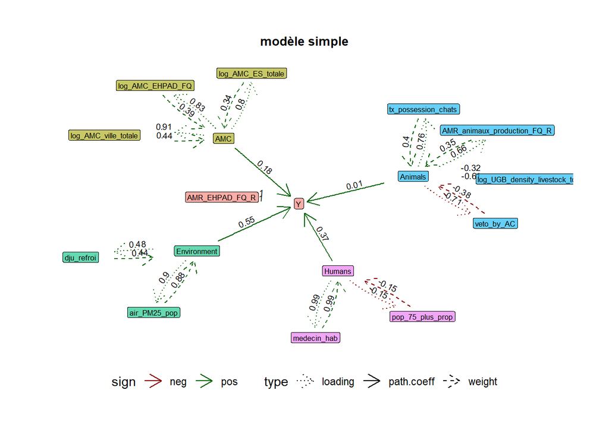

```r
g2
```

### 3.2.9 Coefficients de regression

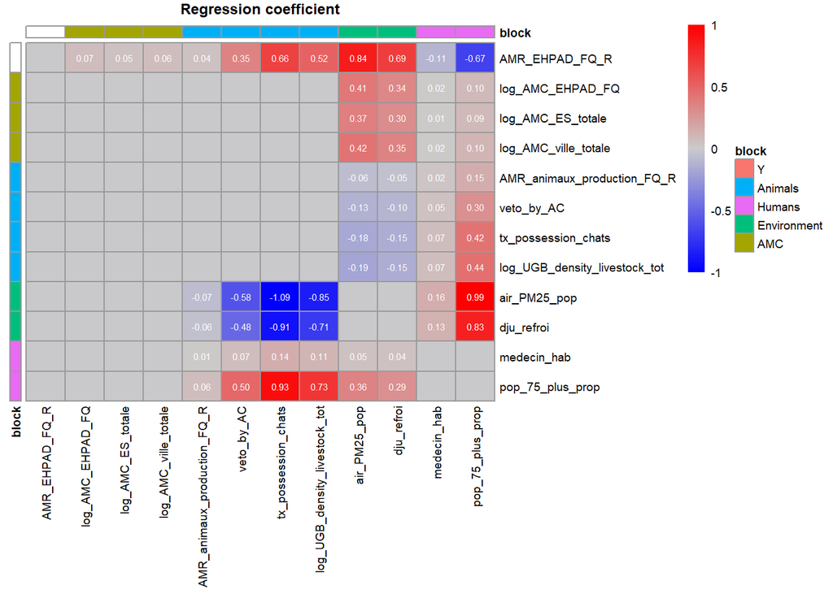

```r
M <- Matrix_reg(model_type = "complet")

cl <- as.data.frame(correspondance_block[which(correspondance_block$term %in% colnames(M)),])
cl <- rbind.data.frame(cl,
data.frame(block = "Y", term = "AMR_ville_FQ_R"))
rownames(cl) <- cl$term
cl <- cl %>% dplyr::select(-term)

disp <- matrix(sprintf("%.2f", M), nrow = nrow(M), ncol = ncol(M))
disp[abs(M) == 0] <- ""

ann_colors <- list(
 block = c(
    Y = "#F8766D",
    Animals = "#00B0F6",
    Humans = "#E76BF3",
    Environment = "#00BF7D",
    AMC = "#A3A500"
  )
)

pheatmap::pheatmap(M,
                          color = colorRampPalette(c("blue", "grey80", "red"))(100),
                          breaks = seq(-1, 1, length.out = 101),
                          cluster_rows = FALSE,
                          cluster_cols = FALSE,
                          # clustering_distance_rows = "euclidean",
                          # clustering_distance_cols = "euclidean",
                          # clustering_method = "ward.D2",
                          number_format = "%.1f",
                          fontsize = 7,
                          number_color = "white",
                          legend = TRUE,
                          legend_breaks = c(-1, -0.5, 0, 0.5, 1),
                          legend_labels = c("-1", "-0.5", "0", "0.5", "1"),
                          angle_col = 90,
                          annotation_row = cl,
                          annotation_col = cl,
                          annotation_colors = ann_colors,
                          display_numbers = disp,
                          main = "Regression coefficient")
```

### 3.2.10 Regresssion Ridge VL

```r
submodels <- c(
  "Y ~ AMC + Animals + Environment + Humans",
  "AMC ~ Humans + Environment",
  "Environment ~ Animals + Humans",
  "Humans ~ Environment + Animals",
  "Animals ~ Environment + Humans")

tab_ridge <- sum_gsca_complet$paths %>%
  dplyr::select(term, path_coeff = estimate) %>%
  dplyr::arrange(desc(term))

# Application à tous les submodels + assemblage
ridge_results <- purrr::map_dfr(submodels, get_ridge_betas, data = latent_coord)

# Jointure avec ton tableau initial
tab_ridge <- tab_ridge %>%
  dplyr::left_join(ridge_results, by = "term")

knitr::kable(tab_ridge, digits = 2)
```

| term | path_coeff | ridge_beta |
| --- | --- | --- |
| Y~Humans | -0.67 | -0.03 |
| Y~Environment | 1.11 | 0.55 |
| Y~Animals | 0.78 | -0.04 |
| Y~AMC | 0.16 | 0.26 |
| Humans~Environment | 0.48 | 0.37 |
| Humans~Animals | 1.12 | 0.98 |
| Environment~Humans | 1.27 | 0.88 |
| Environment~Animals | -1.64 | -1.23 |
| Animals~Humans | 0.80 | 0.74 |
| Animals~Environment | -0.44 | -0.41 |
| AMC~Humans | 0.11 | 0.08 |
| AMC~Environment | 0.63 | 0.52 |

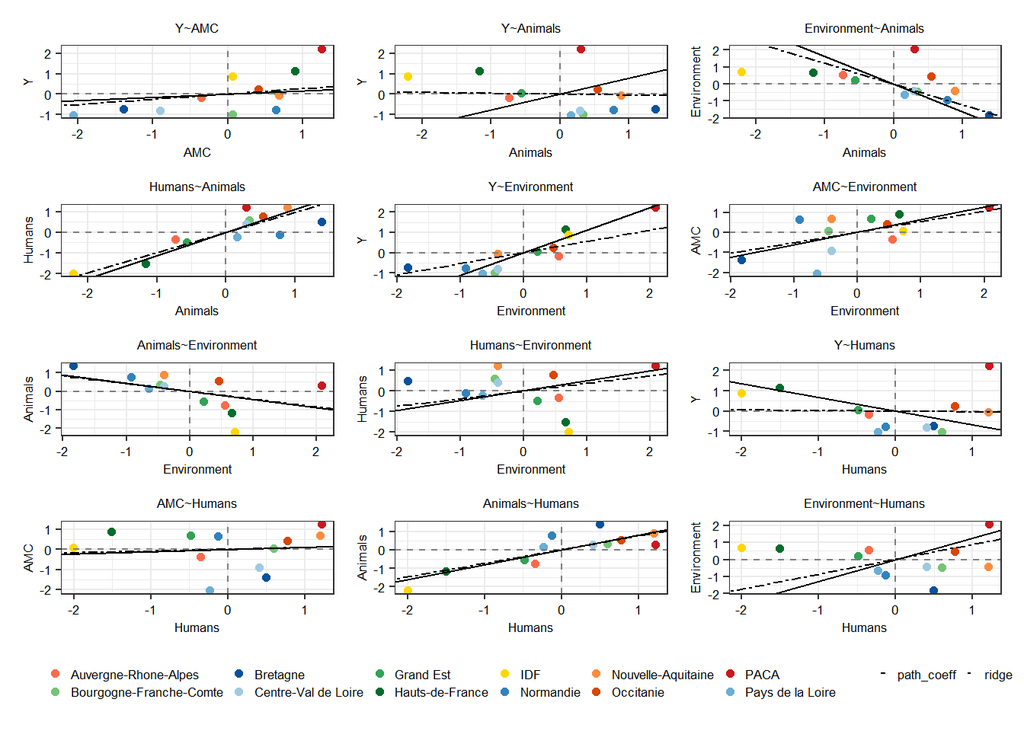

```r
# Appliquer à tous les liens
plot_list <- map(terms, make_scatter2, tab_ridge = tab_ridge) %>%
  set_names(terms)

wrap_plots(plot_list, ncol = 3) +
  plot_layout(guides = "collect") &
  theme(legend.position = "bottom") &
  guides(col = guide_legend(nrow = 2, override.aes = list(size = 1.6)))
```

## 3.3 AMR_ES_FQ_R

Etonnament, le path coeff de Y ~ AMC est très faible (égal à 0,05), nous considérons donc un modèle intermédiaire sans.

### 3.3.1 Unidimensionalité des blocks

On peut supposer que le block AMC est unidimensionnel.

```r
log_AMC_ES_FQ <- dfPC1.AMR_ES_C3G$log_AMC_ES_FQ
dfPC1.AMR_ES_FQ <- cbind.data.frame(dfPC1.AMR_ES_FQ, log_AMC_ES_FQ)
dfPC1.AMR_ES_FQ <- dfPC1.AMR_ES_FQ %>%
  dplyr::relocate(log_AMC_ES_FQ, .before = log_AMC_ES_totale)

dfPC1.AMR_ES_FQ <- scale(dfPC1.AMR_ES_FQ) # standardisation

# Hypothèse d'unidimensionalité des blocks
Xnorm.block <- list(dfPC1.AMR_ES_FQ[,which(colnames(dfPC1.AMR_ES_FQ) %in% c("log_AMC_ES_FQ", "log_AMC_ville_FQ"))],
                    dfPC1.AMR_ES_FQ[,which(colnames(dfPC1.AMR_ES_FQ) %in% c("AMR_animaux_compagnie_C3G_R", "tx_possession_chats", "log_UGB_density_livestock_tot"))],
                    dfPC1.AMR_ES_FQ[,which(colnames(dfPC1.AMR_ES_FQ) %in% c("air_PM25_pop", "dju_refroi"))],
                    dfPC1.AMR_ES_FQ[,which(colnames(dfPC1.AMR_ES_FQ) %in% c("medecin_hab", "pop_75_plus_prop", "EQI_st"))]
                    )

nb.block <- length(Xnorm.block)
order_blocks <- c("AMC", "Animals", "Environment", "Humans")
eigen <- lapply(1:nb.block, function(k) FactoMineR::PCA(Xnorm.block[[k]], scale.unit = TRUE, ncp = 2, graph = F)$eig)
perc_var_comp1 <- c()
for(i in 1:nb.block){
  perc_var_comp1 <- c(perc_var_comp1, eigen[[i]][1,2])
}
df.unim <- data.frame(order_blocks,
                      percentage_variance_PCA_comp1 = round(perc_var_comp1, 2))
knitr::kable(df.unim)
```

| order_blocks | percentage_variance_PCA_comp1 |
| --- | --- |
| AMC | 86.95 |
| Animals | 44.52 |
| Environment | 52.24 |
| Humans | 47.90 |

### 3.3.2 Path coeff

```r
model_simple <- paste(
  paste("Y =~", colnames(dfPC1.AMR_ES_FQ)[1]),
  "AMC =~ log_AMC_ES_FQ + log_AMC_ville_FQ",
  "Animals =~ AMR_animaux_compagnie_C3G_R + tx_possession_chats + log_UGB_density_livestock_tot",
  "Environment =~ dju_refroi + air_PM25_pop",
  "Humans =~ medecin_hab + pop_75_plus_prop + EQI_st",
  "Y ~ AMC + Animals + Environment + Humans",
  sep = "\n\t\t"
)

model_complet <- paste(
  paste("Y =~", colnames(dfPC1.AMR_ES_FQ)[1]),
  "AMC =~ log_AMC_ES_FQ + log_AMC_ville_FQ",
  "Animals =~ AMR_animaux_compagnie_C3G_R + tx_possession_chats + log_UGB_density_livestock_tot",
  "Environment =~ dju_refroi + air_PM25_pop",
  "Humans =~ medecin_hab + pop_75_plus_prop + EQI_st",
  "Y ~ AMC + Animals + Environment + Humans",
  "AMC ~ Humans + Environment",
  "Environment ~ Animals + Humans",
  "Humans ~ Environment + Animals",
  "Animals ~ Environment + Humans",
  sep = "\n\t\t"
)

model_int <- paste(
  paste("Y =~", colnames(dfPC1.AMR_ES_FQ)[1]),
  "AMC =~ log_AMC_ES_FQ + log_AMC_ville_FQ",
  "Animals =~ AMR_animaux_compagnie_C3G_R + tx_possession_chats + log_UGB_density_livestock_tot",
  "Environment =~ dju_refroi + air_PM25_pop",
  "Humans =~ medecin_hab + pop_75_plus_prop + EQI_st",
  "Y ~ Animals + Environment + Humans",
  "AMC ~ Humans + Environment",
  "Environment ~ Animals + Humans",
  "Humans ~ Environment + Animals",
  "Animals ~ Environment + Humans",
  sep = "\n\t\t"
)

set.seed(123)
mod_complet <- gesca::gesca.run(model_complet, dfPC1.AMR_ES_FQ, nbt = 100)
sum_gsca_complet <- summary_gesca2(mod_complet)
mod_simple <- gesca::gesca.run(model_simple, dfPC1.AMR_ES_FQ, nbt = 100)
sum_gsca_simple <- summary_gesca2(mod_simple)
mod_int <- gesca::gesca.run(model_int, dfPC1.AMR_ES_FQ, nbt = 10)
sum_gsca_int <- summary_gesca2(mod_int)


paths_complet <- sum_gsca_complet$paths
paths_complet$model <- rep("complet", nrow(paths_complet))
paths_simple <- sum_gsca_simple$paths
paths_simple$model <- rep("simple", nrow(paths_simple))
paths_int <- sum_gsca_int$paths
paths_int$model <- rep("int", nrow(paths_int))
paths <- rbind.data.frame(paths_complet, paths_simple, paths_int)

DT::datatable(paths)
```

|  | group | term | estimate | std.error | ci_lb | ci_ub | model |
| --- | --- | --- | --- | --- | --- | --- | --- |
| 1 | all | Y~AMC | 0.0575 | 5.7306 | -6.7797 | 5.9287 | complet |
| 2 | all | Y~Animals | 0.658 | 14.048 | -39.3967 | 38.2976 | complet |
| 3 | all | Environment~Animals | -0.4625 | 1.6809 | -3.856 | 1.5879 | complet |
| 4 | all | Humans~Animals | -0.5777 | 0.6846 | -1.2192 | 1.5367 | complet |
| 5 | all | Y~Environment | 0.5065 | 20.6079 | -76.7227 | 48.0453 | complet |
| 6 | all | AMC~Environment | 1.1437 | 1.722 | -3.2979 | 3.2935 | complet |
| 7 | all | Animals~Environment | -0.3319 | 1.4692 | -2.291 | 2.7157 | complet |
| 8 | all | Humans~Environment | -0.4498 | 0.8069 | -1.472 | 1.0898 | complet |
| 9 | all | Y~Humans | 0.2516 | 26.5455 | -40.8322 | 75.647 | complet |
| 10 | all | AMC~Humans | 0.5684 | 1.6376 | -3.0457 | 2.7518 | complet |

[output cut: 17 more lines]

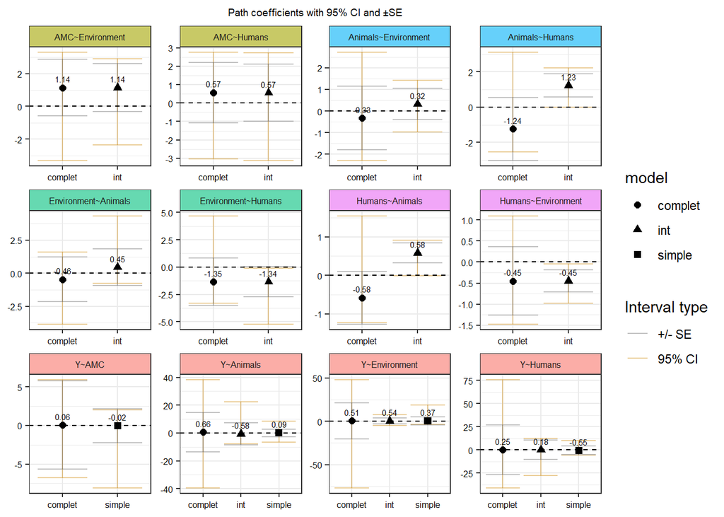

```r
paths$outcome <- str_remove(paths$term, "~.*")

outcomes <- unique(paths$outcome)
pal <- setNames(c("#F8766D", "#00BF7D", "#E76BF3",
                  "#A3A500", "#00B0F6"), outcomes)

term_outcome_map <- setNames(paths$outcome, paths$term)
term_levels <- sort(unique(paths$term))
# applique 0.6 d'opacité à chaque couleur de la palette
pal_alpha <- scales::alpha(pal, 0.6)
strip_colors <- pal_alpha[term_outcome_map[term_levels]]


ggplot(paths, aes(x = model, y = estimate)) +
    geom_errorbar(aes(ymin = ci_lb, ymax = ci_ub, color = "95% CI"),
                   height = 0.1, alpha = 0.4) +
    geom_errorbar(aes(ymin = estimate - std.error,
                       ymax = estimate + std.error,
                       color = "+/- SE"),
                   height = 0.1, linewidth = 0.4, alpha = 0.4) +
    geom_point(aes(shape = model), size = 2) +
    geom_text(aes(label = round(estimate, 2)),
              size = 2, vjust = -0.86)+
    geom_hline(yintercept = 0, linetype = "dashed") +
    ggh4x::facet_wrap2(~ term, scales = "free",
                       strip = strip_themed(
      background_x = elem_list_rect(fill = strip_colors)
    ))+
    theme_bw() +
    labs(title = "Path coefficients with 95% CI and ±SE")+
    theme(axis.text = element_text(color = "black", size = 6),
          axis.title = element_blank(),
          plot.title = element_text(hjust = 0.5, size = 7),
          strip.text = element_text(size = 6))+
  scale_color_manual(name = "Interval type",
                     values = c(
                       "95% CI" = "orange3",
                       "+/- SE" = "grey40"))
```

### 3.3.3 Loadings

```r
loadings_complet <- sum_gsca_complet$loadings
loadings_complet$model <- rep("complet", nrow(loadings_complet))
loadings_simple <- sum_gsca_simple$loadings
loadings_simple$model <- rep("simple", nrow(loadings_simple))
loadings_int <- sum_gsca_int$loadings
loadings_int$model <- rep("int", nrow(loadings_int))
loadings <- rbind.data.frame(loadings_complet, loadings_simple, loadings_int)

DT::datatable(loadings)
```

|  | group | term | estimate | std.error | ci_lb | ci_ub | model |
| --- | --- | --- | --- | --- | --- | --- | --- |
| 1 | all | AMR_ES_FQ_R | 1 | 0 | 1 | 1 | complet |
| 2 | all | log_AMC_ES_FQ | 0.9282 | 0.7559 | -0.9879 | 0.9937 | complet |
| 3 | all | log_AMC_ville_FQ | 0.9366 | 0.7929 | -0.9912 | 0.9918 | complet |
| 4 | all | AMR_animaux_compagnie_C3G_R | 0.5984 | 0.5966 | -0.9281 | 0.9526 | complet |
| 5 | all | tx_possession_chats | -0.1373 | 0.6425 | -0.918 | 0.9491 | complet |
| 6 | all | log_UGB_density_livestock_tot | -0.8948 | 0.5654 | -0.9886 | 0.9441 | complet |
| 7 | all | air_PM25_pop | 0.8491 | 0.2839 | -0.6133 | 0.9997 | complet |
| 8 | all | dju_refroi | 0.5658 | 0.5767 | -0.896 | 0.9522 | complet |
| 9 | all | EQI_st | 0.8585 | 0.8053 | -0.9857 | 0.9588 | complet |
| 10 | all | medecin_hab | -0.6331 | 0.6286 | -0.9433 | 0.905 | complet |

[output cut: 23 more lines]

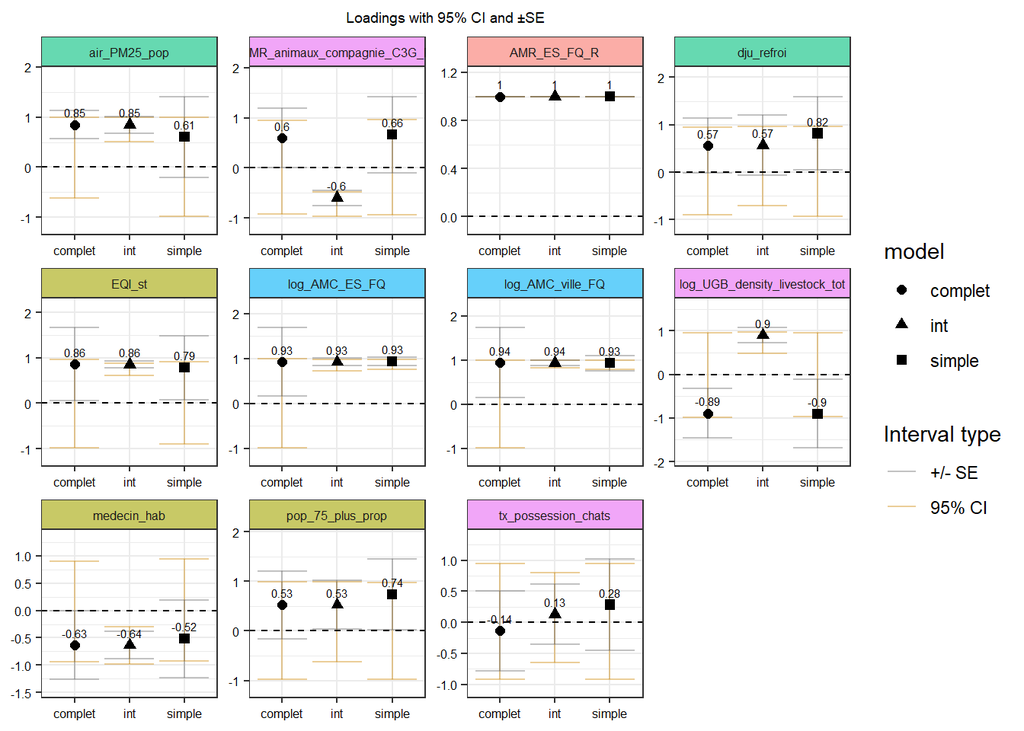

```r
loadings <- loadings %>% dplyr::left_join(correspondance_block,
                              by = "term")
loadings$block <- ifelse(is.na(loadings$block),
                         "Y", loadings$block)

blocks <- unique(loadings$block)
pal <- setNames(c("#F8766D", "#00B0F6", "#E76BF3",
                  "#00BF7D", "#A3A500"), blocks)
term_loadings_map <- setNames(loadings$block, loadings$term)
term_levels <- sort(unique(loadings$term))
# applique 0.6 d'opacité à chaque couleur de la palette
pal_alpha <- scales::alpha(pal, 0.6)
strip_colors <- pal_alpha[term_loadings_map[term_levels]]


ggplot(loadings, aes(x = model, y = estimate)) +
    geom_errorbar(aes(ymin = ci_lb, ymax = ci_ub, color = "95% CI"),
                   height = 0.1, alpha = 0.4) +
    geom_errorbar(aes(ymin = estimate - std.error,
                       ymax = estimate + std.error,
                       color = "+/- SE"),
                   height = 0.1, linewidth = 0.4, alpha = 0.4) +
    geom_point(aes(shape = model), size = 2) +
    geom_text(aes(label = round(estimate, 2)), size = 2, vjust = -0.86)+
    geom_hline(yintercept = 0, linetype = "dashed") +
    ggh4x::facet_wrap2(~ term, scales = "free",
                       strip = strip_themed(
      background_x = elem_list_rect(fill = strip_colors)
    ))+
    theme_bw() +
    scale_y_continuous(expand = expansion(mult = c(0.15, 0.25)))+
    labs(title = "Loadings with 95% CI and ±SE")+
    theme(axis.text = element_text(color = "black", size = 6),
          axis.title = element_blank(),
          plot.title = element_text(hjust = 0.5, size = 7),
          strip.text = element_text(size = 6))+
  scale_color_manual(name = "Interval type",
                     values = c(
                       "95% CI" = "orange3",
                       "+/- SE" = "grey40"))
```

### 3.3.4 Weight

```r
weights_complet <- sum_gsca_complet$weights
weights_complet$model <- rep("complet", nrow(weights_complet))
weights_simple <- sum_gsca_simple$weights
weights_simple$model <- rep("simple", nrow(weights_simple))
weights_int <- sum_gsca_int$weights
weights_int$model <- rep("int", nrow(weights_int))
weights <- rbind.data.frame(weights_complet, weights_simple, weights_int)

DT::datatable(weights)
```

|  | group | term | estimate | std.error | ci_lb | ci_ub | model |
| --- | --- | --- | --- | --- | --- | --- | --- |
| 1 | all | AMR_ES_FQ_R | 1 | 0 | 1 | 1 | complet |
| 2 | all | log_AMC_ES_FQ | 0.5197 | 0.4444 | -0.7629 | 0.7349 | complet |
| 3 | all | log_AMC_ville_FQ | 0.5526 | 0.5036 | -0.8496 | 0.7782 | complet |
| 4 | all | AMR_animaux_compagnie_C3G_R | 0.202 | 0.3193 | -0.586 | 0.6048 | complet |
| 5 | all | tx_possession_chats | -0.3525 | 0.4049 | -0.6479 | 0.6581 | complet |
| 6 | all | log_UGB_density_livestock_tot | -0.9285 | 0.5308 | -1.0657 | 0.7479 | complet |
| 7 | all | air_PM25_pop | 0.825 | 0.2689 | -0.2291 | 1.0288 | complet |
| 8 | all | dju_refroi | 0.5294 | 0.4036 | -0.6691 | 0.8002 | complet |
| 9 | all | EQI_st | 0.6341 | 0.5935 | -0.9444 | 0.9224 | complet |
| 10 | all | medecin_hab | -0.469 | 0.3888 | -0.6547 | 0.5717 | complet |

[output cut: 23 more lines]

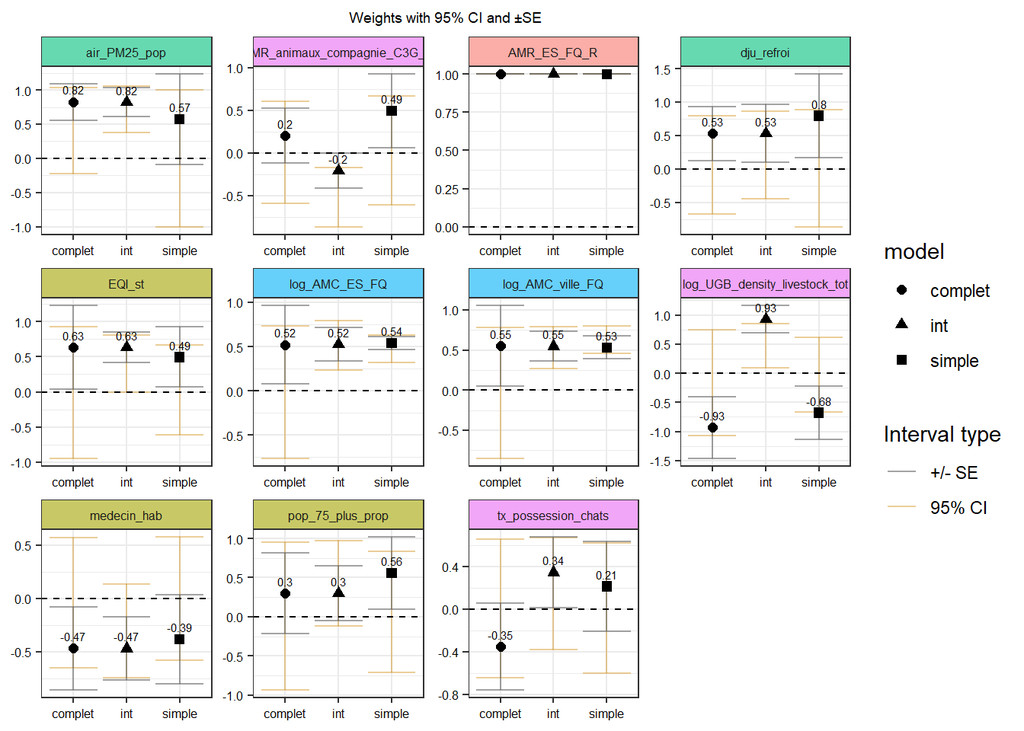

```r
weights <- weights %>% dplyr::left_join(correspondance_block,
                              by = "term")
weights$block <- ifelse(is.na(weights$block),
                         "Y", weights$block)

blocks <- unique(weights$block)
pal <- setNames(c("#F8766D", "#00B0F6", "#E76BF3",
                  "#00BF7D", "#A3A500"), blocks)
term_weights_map <- setNames(weights$block, weights$term)
term_levels <- sort(unique(weights$term))
# applique 0.6 d'opacité à chaque couleur de la palette
pal_alpha <- scales::alpha(pal, 0.6)
strip_colors <- pal_alpha[term_loadings_map[term_levels]]


ggplot(weights, aes(x = model, y = estimate)) +
    geom_errorbar(aes(ymin = ci_lb, ymax = ci_ub, color = "95% CI"),
                   height = 0.1, alpha = 0.4) +
    geom_errorbar(aes(ymin = estimate - std.error,
                       ymax = estimate + std.error,
                       color = "+/- SE"),
                   height = 0.1, linewidth = 0.4, alpha = 0.6, alpha = 0.4) +
   geom_text(aes(label = round(estimate, 2)), size = 2,
            vjust = -0.86) +
    geom_point(aes(shape = model), size = 2) +
    geom_hline(yintercept = 0, linetype = "dashed") +
    ggh4x::facet_wrap2(~ term, scales = "free",
                       strip = strip_themed(
      background_x = elem_list_rect(fill = strip_colors)))+
    theme_bw() +
    labs(title = "Weights with 95% CI and ±SE")+
    theme(axis.text = element_text(color = "black", size = 6),
          axis.title = element_blank(),
          plot.title = element_text(hjust = 0.5, size = 7),
          strip.text = element_text(size = 6))+
  scale_color_manual(name = "Interval type",
                     values = c(
                       "95% CI" = "orange3",
                       "+/- SE" = "grey40"))
```

### 3.3.5 R2

Le modèle intermédiaire et lemodèle complet donnent les mêmes résultats de performance des sous-modèles. Le modèle simple est un tout petit peu mieux pour le modèle principal

```r
# corrélations entre composantes latentes
# complet
latentcorr_complet <- mod_complet$latentcorr
rownames(latentcorr_complet) <- c("Y", "AMC", "Animals", "Environment", "Humans")
colnames(latentcorr_complet) <- c("Y", "AMC", "Animals", "Environment", "Humans")
# int
latentcorr_int <- mod_int$latentcorr
rownames(latentcorr_int) <- c("Y", "AMC", "Animals", "Environment", "Humans")
colnames(latentcorr_int) <- c("Y", "AMC", "Animals", "Environment", "Humans")
# simple
latentcorr_simple <- mod_simple$latentcorr
rownames(latentcorr_simple) <- c("Y", "AMC", "Animals", "Environment", "Humans")
colnames(latentcorr_simple) <- c("Y", "AMC", "Animals", "Environment", "Humans")

R2 <- data.frame(term = sum_gsca_complet$paths$term,
                 R2_model_complet = rep(NA, length(sum_gsca_complet$paths$term)),
                 R2_model_int = rep(NA, length(sum_gsca_complet$paths$term)),
                 R2_model_simple = rep(NA, length(sum_gsca_complet$paths$term)))

for (i in 1:nrow(R2)){
  # complet
  beta_comp_block <- sum_gsca_complet$paths$estimate[sum_gsca_complet$paths$term == R2$term[i]]
r_block_comp <- latentcorr_complet[stringr::str_split(R2$term[i], "~")[[1]][1], stringr::str_split(R2$term[i], "~")[[1]][2]]
R2[i,]$R2_model_complet <- beta_comp_block * r_block_comp
# intermédiaire
if (R2$term[i] %in% sum_gsca_int$paths$term){
beta_int_block <- sum_gsca_int$paths$estimate[sum_gsca_int$paths$term == R2$term[i]]
r_block_int <- latentcorr_int[stringr::str_split(R2$term[i], "~")[[1]][1], stringr::str_split(R2$term[i], "~")[[1]][2]]
R2[i,]$R2_model_int <- beta_int_block * r_block_int}
else {R2[i,]$R2_model_int <- NA}
# simple
if (R2$term[i] %in% sum_gsca_simple$paths$term){
beta_simple_block <- sum_gsca_simple$paths$estimate[sum_gsca_simple$paths$term == R2$term[i]]
r_block_simple <- latentcorr_simple[stringr::str_split(R2$term[i], "~")[[1]][1], stringr::str_split(R2$term[i], "~")[[1]][2]]
R2[i,]$R2_model_simple <- beta_simple_block * r_block_simple}
else {R2[i,]$R2_model_simple <- NA}
}

knitr::kable(R2, digits = 2)
```

| term | R2_model_complet | R2_model_int | R2_model_simple |
| --- | --- | --- | --- |
| Y~AMC | 0.02 | NA | -0.01 |
| Y~Animals | 0.56 | 0.49 | 0.06 |
| Environment~Animals | -0.37 | -0.36 | NA |
| Humans~Animals | 0.54 | 0.54 | NA |
| Y~Environment | 0.43 | 0.45 | 0.29 |
| AMC~Environment | 0.71 | 0.71 | NA |
| Animals~Environment | -0.27 | -0.26 | NA |
| Humans~Environment | 0.41 | 0.41 | NA |
| Y~Humans | -0.22 | -0.16 | 0.46 |
| AMC~Humans | -0.27 | -0.27 | NA |
| Animals~Humans | 1.17 | 1.16 | NA |
| Environment~Humans | 1.23 | 1.22 | NA |

```r
# Les R2 par blocs
r2 <- data.frame(
  var = c("Y", "AMC", "Animals", "Environment", "Humans"),
  R2_model_complet = round(mod_complet$R2[1,], 2),
  R2_model_int = round(mod_int$R2[1,], 2),
  R2_model_simple = round(mod_simple$R2[1,], 2)
)

knitr::kable(r2)
```

| var | R2_model_complet | R2_model_int | R2_model_simple |
| --- | --- | --- | --- |
| Y | 0.79 | 0.79 | 0.81 |
| AMC | 0.44 | 0.44 | 0.00 |
| Animals | 0.90 | 0.90 | 0.00 |
| Environment | 0.86 | 0.86 | 0.00 |
| Humans | 0.95 | 0.95 | 0.00 |

### 3.3.6 FIT

Le modèle complet et le modèle intermédiaire sont à peu près équivalents en termes de performance globale. Plus que le modèle simple. Le modèle intermédiaire semble être plus précis dans l’estimation du GFI. Comme quoi en etablissement de santé le lien resistance ~ consommation n’est pas si explicatif que ça…

```r
fit_complet <- featmeasures2(mod_complet)
```

```
##   Number of parameters        34
##   Number of bootstrap samples 100
##
##  Measure  Estimate    Std.Error        CI_LB    CI_UB
##      FIT    0.6450 4.010000e-02  6.57100e-01   0.8184
##     AFIT    0.5219 5.400000e-02  5.38200e-01   0.7554
##      GFI -289.3434 2.949055e+07 -3.20035e+07 -65.7930
##     SRMR    0.6215 8.030000e-02  4.02200e-01   0.7056
##    FIT_M    0.5794 5.220000e-02  5.49500e-01   0.7778
##    FIT_S    0.7895 6.060000e-02  7.30100e-01   0.9794
```

```r
fit_complet$model <- rep("complet", nrow(fit_complet))
fit_simple <- featmeasures2(mod_simple)
```

```
##   Number of parameters        26
##   Number of bootstrap samples 100
##
##  Measure Estimate  Std.Error       CI_LB  CI_UB
##      FIT   0.4595     0.0335      0.4643 0.5954
##     AFIT   0.3269     0.0417      0.3329 0.4961
##      GFI   0.9642 23490.3869 -68964.7202 0.9873
##     SRMR   0.3858     0.0494      0.3797 0.5882
##    FIT_M   0.5951     0.0467      0.5955 0.7751
##    FIT_S   0.1613     0.0168      0.1413 0.2000
```

```r
fit_simple$model <- rep("simple", nrow(fit_simple))
fit_int <- featmeasures2(mod_int)
```

```
##   Number of parameters        33
##   Number of bootstrap samples 10
##
##  Measure  Estimate    Std.Error         CI_LB     CI_UB
##      FIT    0.6450       0.0461        0.6555    0.8176
##     AFIT    0.5266       0.0615        0.5407    0.7568
##      GFI -278.4084 1452741.0780 -4608321.6159 -143.1815
##     SRMR    0.6173       0.0886        0.3982    0.7247
##    FIT_M    0.5797       0.0555        0.5714    0.7541
##    FIT_S    0.7885       0.0615        0.7930    0.9574
```

```r
fit_int$model <- rep("int", nrow(fit_int))
fit <- rbind.data.frame(fit_complet, fit_simple, fit_int)

DT::datatable(fit)
```

|  | Measure | Estimate | Std.Error | CI_LB | CI_UB | model |
| --- | --- | --- | --- | --- | --- | --- |
| 1 | FIT | 0.645 | 0.0401 | 0.6571 | 0.8184 | complet |
| 2 | AFIT | 0.5219 | 0.054 | 0.5382 | 0.7554 | complet |
| 3 | GFI | -289.3434 | 29490548.6244 | -32003504.8306 | -65.793 | complet |
| 4 | SRMR | 0.6215 | 0.0803 | 0.4022 | 0.7056 | complet |
| 5 | FIT_M | 0.5794 | 0.0522 | 0.5495 | 0.7778 | complet |
| 6 | FIT_S | 0.7895 | 0.0606 | 0.7301 | 0.9794 | complet |
| 7 | FIT | 0.4595 | 0.0335 | 0.4643 | 0.5954 | simple |
| 8 | AFIT | 0.3269 | 0.0417 | 0.3329 | 0.4961 | simple |
| 9 | GFI | 0.9642 | 23490.3869 | -68964.7202 | 0.9873 | simple |
| 10 | SRMR | 0.3858 | 0.0494 | 0.3797 | 0.5882 | simple |

[output cut: 8 more lines]

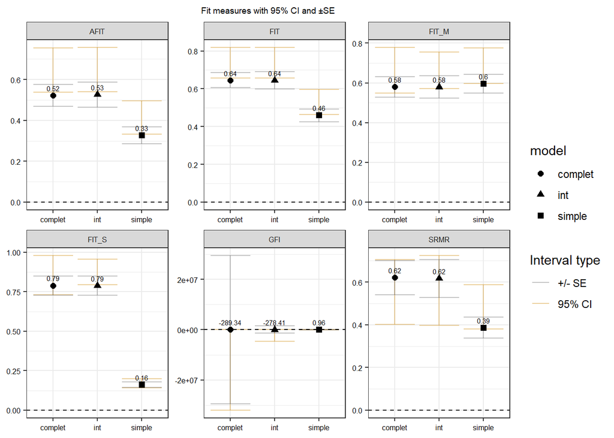

```r
ggplot(fit, aes(x = model, y = Estimate)) +
    geom_errorbar(aes(ymin = CI_LB, ymax = CI_UB, color = "95% CI"),
                   height = 0.1, alpha = 0.4) +
    geom_errorbar(aes(ymin = Estimate - Std.Error,
                       ymax = Estimate + Std.Error,
                       color = "+/- SE"),
                   height = 0.1, linewidth = 0.4, alpha = 0.4) +
    geom_point(aes(shape = model), size = 2) +
    geom_text(aes(label = round(Estimate, 2)), size = 2,              vjust = -0.86)+
    geom_hline(yintercept = 0, linetype = "dashed") +
    facet_wrap(~ Measure, scales = "free")+
    theme_bw() +
    labs(title = "Fit measures with 95% CI and ±SE")+
    theme(axis.text = element_text(color = "black", size = 6),
          axis.title = element_blank(),
          plot.title = element_text(hjust = 0.5, size = 7),
          strip.text = element_text(size = 6))+
  scale_color_manual(name = "Interval type",
                     values = c(
                       "95% CI" = "orange3",
                       "+/- SE" = "grey40"))
```

### 3.3.7 Scatterplot VL

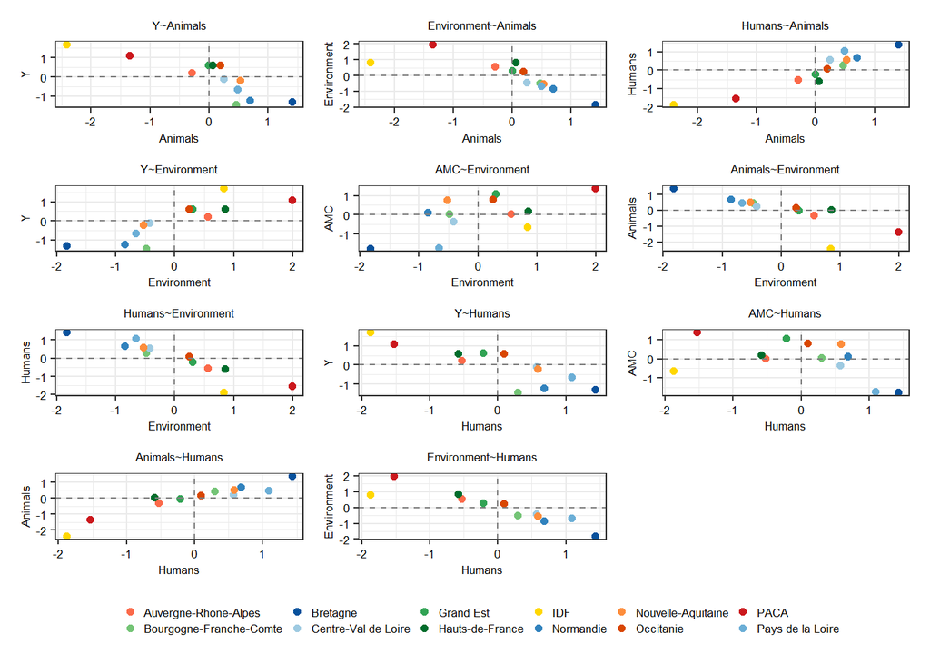

```r
#dimnames(mod_int$WR)
rownames(mod_int$WR) <- sum_gsca_complet$weights$term
colnames(mod_int$WR) <- c("Y", "AMC", "Animals",
                          "Environment", "Humans")

indicateur <- rownames(mod_int$WR)
X <- scale(dfPC1.AMR_ES_FQ[, indicateur])
latent_coord <- X %*% mod_int$WR

# 1. Transformer la matrice en data frame avec une colonne "id" pour la couleur
df_coord <- as.data.frame(latent_coord) %>%
  rownames_to_column("id")

# 2. Récupérer les termes
terms <- sum_gsca_int$paths$term

plot_list <- map(terms, make_scatter) %>%
  set_names(terms)

wrap_plots(plot_list, ncol = 3) +
  plot_layout(guides = "collect") &
  theme(legend.position = "bottom") &
  guides(col = guide_legend(nrow = 2, override.aes = list(size = 1.6)))
```

```r
# ggsave("C:/Users/g.martet/Documents/functional_study/figures diapo/scatterplot_VL_AMR_ES_FQ.png", width = 7, height = 7)
```

### 3.3.8 graphes

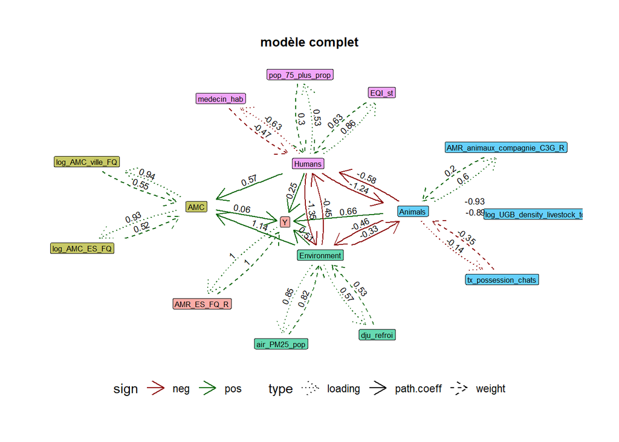

```r
#-----------------------
# construire le dataset
#-----------------------

# les paths
paths$from <- str_remove(paths$term, ".*~")
paths2 <- paths %>%
  dplyr::rename(to = "outcome") %>%
  dplyr::select(from, to, estimate, model) %>%
  dplyr::mutate(sign = ifelse(estimate >=0, "pos", "neg")) %>%
  dplyr::mutate(block = from) %>%
  dplyr::mutate(type = "path.coeff")
# les weights
weights2 <- weights %>%
  dplyr::rename(from = "term", to = "block") %>%
  dplyr::select(from, to, estimate, model) %>%
  dplyr::mutate(sign = ifelse(estimate >=0, "pos", "neg")) %>%
  dplyr::mutate(block = to) %>%
  dplyr::mutate(type = "weight")
# les loadings
loadings2 <- loadings %>%
  dplyr::rename(from = "block", to = "term") %>%
  dplyr::select(from, to, estimate, model) %>%
  dplyr::mutate(sign = ifelse(estimate >=0, "pos", "neg")) %>%
  dplyr::mutate(block = from) %>%
  dplyr::mutate(type = "loading")

dat_graph <- rbind(paths2, weights2, loadings2)

#----------------------
# modèle complet
#----------------------

dat_filtered <- dat_graph %>%
  dplyr::filter(model == "complet")

# Construire le tableau des noeuds avec leur block
nodes_df <- dplyr::bind_rows(
  dat_filtered %>% dplyr::select(name = from, block),
  dat_filtered %>% dplyr::select(name = to, block)
) %>%
  dplyr::filter(!is.na(block)) %>%   # garde les lignes où block est renseigné
  dplyr::distinct(name, .keep_all = TRUE)  # une ligne par noeud

# Construire le graphe explicitement
graph <- tbl_graph(
  nodes = nodes_df,
  edges = dat_filtered %>% dplyr::select(from, to, estimate, sign, type),
  node_key = "name"
)

g1 <- ggraph(graph) +
  geom_edge_fan(aes(colour = sign,
                     end_cap = label_rect(node2.name),
                     start_cap = label_rect(node1.name),
                    label = round(estimate, 2),
                    linetype = type),
                arrow = arrow(length = unit(4, 'mm')),
                label_dodge = unit(1.8, 'mm'),
                angle_calc = "along",
                label_size = 2.5) +
  geom_node_label(aes(label = name, fill = block), size = 2.2,
                  show.legend = FALSE, alpha = 0.6) +
  labs(title = "modèle complet")+
  scale_x_continuous(expand = expansion(mult = 0.10)) +
  ggraph::theme_graph(background = 'white') +
  theme(legend.position = "bottom") +
  theme(plot.title = element_text(hjust = 0.5, size = 10))+
  scale_edge_colour_manual(values = c("darkred", "darkgreen"))+
  scale_edge_linetype_manual(values = c(path.coeff = "solid", weight = "dashed", loading = "dotted"))+
  scale_fill_manual(values = c(Y = "#F8766D", Animals = "#00B0F6", Humans = "#E76BF3",
                  Environment = "#00BF7D", AMC = "#A3A500"))

#----------------------
# modèle intermédiaire
#----------------------

dat_filtered <- dat_graph %>%
  dplyr::filter(model == "int")

# Construire le tableau des noeuds avec leur block
nodes_df <- dplyr::bind_rows(
  dat_filtered %>% dplyr::select(name = from, block),
  dat_filtered %>% dplyr::select(name = to, block)
) %>%
  dplyr::filter(!is.na(block)) %>%   # garde les lignes où block est renseigné
  dplyr::distinct(name, .keep_all = TRUE)  # une ligne par noeud

# Construire le graphe explicitement
graph <- tbl_graph(
  nodes = nodes_df,
  edges = dat_filtered %>% dplyr::select(from, to, estimate, sign, type),
  node_key = "name"
)

g2 <- ggraph(graph) +
  geom_edge_fan(aes(colour = sign,
                     end_cap = label_rect(node2.name),
                     start_cap = label_rect(node1.name),
                    label = round(estimate, 2),
                    linetype = type),
                arrow = arrow(length = unit(4, 'mm')),
                label_dodge = unit(1.8, 'mm'),
                angle_calc = "along",
                label_size = 2.5) +
  geom_node_label(aes(label = name, fill = block), size = 2.2,
                  show.legend = FALSE, alpha = 0.6) +
  labs(title = "modèle intermédiaire")+
  ggraph::theme_graph(background = 'white') +
  theme(legend.position = "bottom") +
  scale_x_continuous(expand = expansion(mult = 0.10)) +
  theme(plot.title = element_text(hjust = 0.5, size = 10))+
  scale_edge_colour_manual(values = c("darkred", "darkgreen"))+
  scale_edge_linetype_manual(values = c(path.coeff = "solid", weight = "dashed", loading = "dotted"))+
  scale_fill_manual(values = c(Y = "#F8766D", Animals = "#00B0F6", Humans = "#E76BF3",
                  Environment = "#00BF7D", AMC = "#A3A500"))

#----------------------
# modèle simple
#----------------------

dat_filtered <- dat_graph %>%
  dplyr::filter(model == "simple")

# Construire le tableau des noeuds avec leur block
nodes_df <- dplyr::bind_rows(
  dat_filtered %>% dplyr::select(name = from, block),
  dat_filtered %>% dplyr::select(name = to, block)
) %>%
  dplyr::filter(!is.na(block)) %>%   # garde les lignes où block est renseigné
  dplyr::distinct(name, .keep_all = TRUE)  # une ligne par noeud

# Construire le graphe explicitement
graph <- tbl_graph(
  nodes = nodes_df,
  edges = dat_filtered %>% dplyr::select(from, to, estimate, sign, type),
  node_key = "name"
)

g3 <- ggraph(graph) +
  geom_edge_fan(aes(colour = sign,
                     end_cap = label_rect(node2.name),
                     start_cap = label_rect(node1.name),
                    label = round(estimate, 2),
                    linetype = type),
                arrow = arrow(length = unit(4, 'mm')),
                label_dodge = unit(1.8, 'mm'),
                angle_calc = "along",
                label_size = 2.5) +
  geom_node_label(aes(label = name, fill = block), size = 2.2,
                  show.legend = FALSE, alpha = 0.6) +
  labs(title = "modèle simple")+
  scale_x_continuous(expand = expansion(mult = 0.10)) +
  ggraph::theme_graph(background = 'white') +
  theme(legend.position = "bottom") +
  theme(plot.title = element_text(hjust = 0.5, size = 10))+
  scale_edge_colour_manual(values = c("darkred", "darkgreen"))+
  scale_edge_linetype_manual(values = c(path.coeff = "solid", weight = "dashed", loading = "dotted"))+
  scale_fill_manual(values = c(Y = "#F8766D", Animals = "#00B0F6", Humans = "#E76BF3",
                  Environment = "#00BF7D", AMC = "#A3A500"))

g1
```

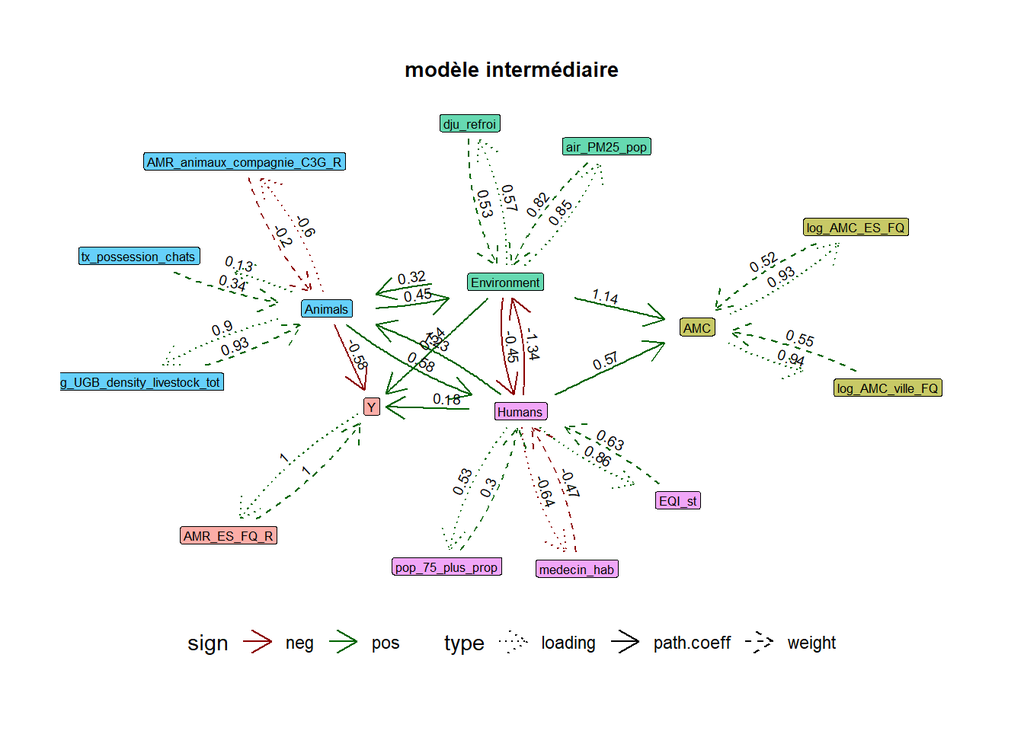

```r
g2
```

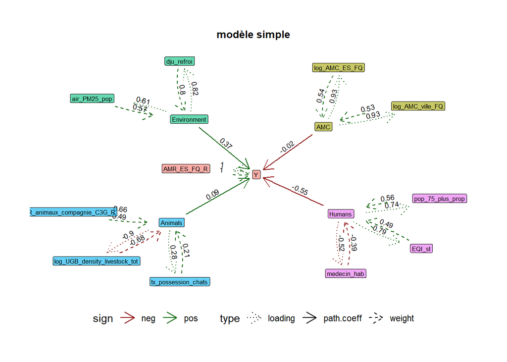

```r
g3
```

### 3.3.9 Coefficients de regression

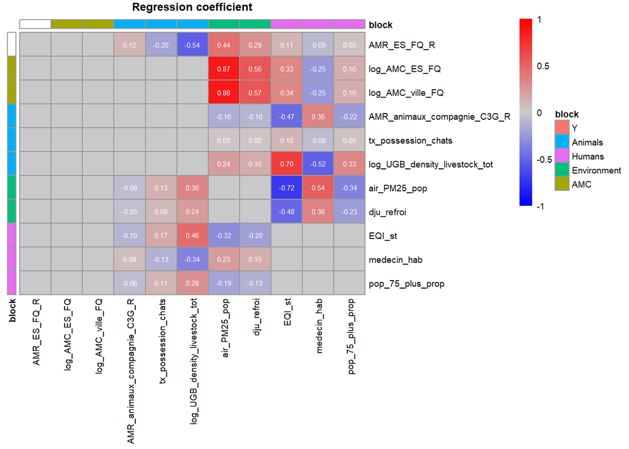

```r
M <- Matrix_reg(model_type = "int")

cl <- as.data.frame(correspondance_block[which(correspondance_block$term %in% colnames(M)),])
cl <- rbind.data.frame(cl,
data.frame(block = "Y", term = "AMR_ville_FQ_R"))
rownames(cl) <- cl$term
cl <- cl %>% dplyr::select(-term)

disp <- matrix(sprintf("%.2f", M), nrow = nrow(M), ncol = ncol(M))
disp[abs(M) == 0] <- ""

ann_colors <- list(
 block = c(
    Y = "#F8766D",
    Animals = "#00B0F6",
    Humans = "#E76BF3",
    Environment = "#00BF7D",
    AMC = "#A3A500"
  )
)

pheatmap::pheatmap(M,
                          color = colorRampPalette(c("blue", "grey80", "red"))(100),
                          breaks = seq(-1, 1, length.out = 101),
                          cluster_rows = FALSE,
                          cluster_cols = FALSE,
                          # clustering_distance_rows = "euclidean",
                          # clustering_distance_cols = "euclidean",
                          # clustering_method = "ward.D2",
                          number_format = "%.1f",
                          fontsize = 7,
                          number_color = "white",
                          legend = TRUE,
                          legend_breaks = c(-1, -0.5, 0, 0.5, 1),
                          legend_labels = c("-1", "-0.5", "0", "0.5", "1"),
                          angle_col = 90,
                          annotation_row = cl,
                          annotation_col = cl,
                          annotation_colors = ann_colors,
                          display_numbers = disp,
                          main = "Regression coefficient")
```

### 3.3.10 Regresssion Ridge VL

```r
submodels <- c("Y ~ Animals + Environment + Humans",
  "AMC ~ Humans + Environment",
  "Environment ~ Animals + Humans",
  "Humans ~ Environment + Animals",
  "Animals ~ Environment + Humans")

tab_ridge <- sum_gsca_int$paths %>%
  dplyr::select(term, path_coeff = estimate) %>%
  dplyr::arrange(desc(term))

# Application à tous les submodels + assemblage
ridge_results <- purrr::map_dfr(submodels, get_ridge_betas, data = latent_coord)

# Jointure avec ton tableau initial
tab_ridge <- tab_ridge %>%
  dplyr::left_join(ridge_results, by = "term")

knitr::kable(tab_ridge, digits = 2)
```

| term | path_coeff | ridge_beta |
| --- | --- | --- |
| Y~Humans | 0.18 | -0.24 |
| Y~Environment | 0.54 | 0.29 |
| Y~Animals | -0.58 | -0.28 |
| Humans~Environment | -0.45 | -0.43 |
| Humans~Animals | 0.58 | 0.51 |
| Environment~Humans | -1.34 | -0.41 |
| Environment~Animals | 0.45 | -0.25 |
| Animals~Humans | 1.23 | 0.69 |
| Animals~Environment | 0.32 | -0.15 |
| AMC~Humans | 0.57 | -0.12 |
| AMC~Environment | 1.14 | 0.27 |

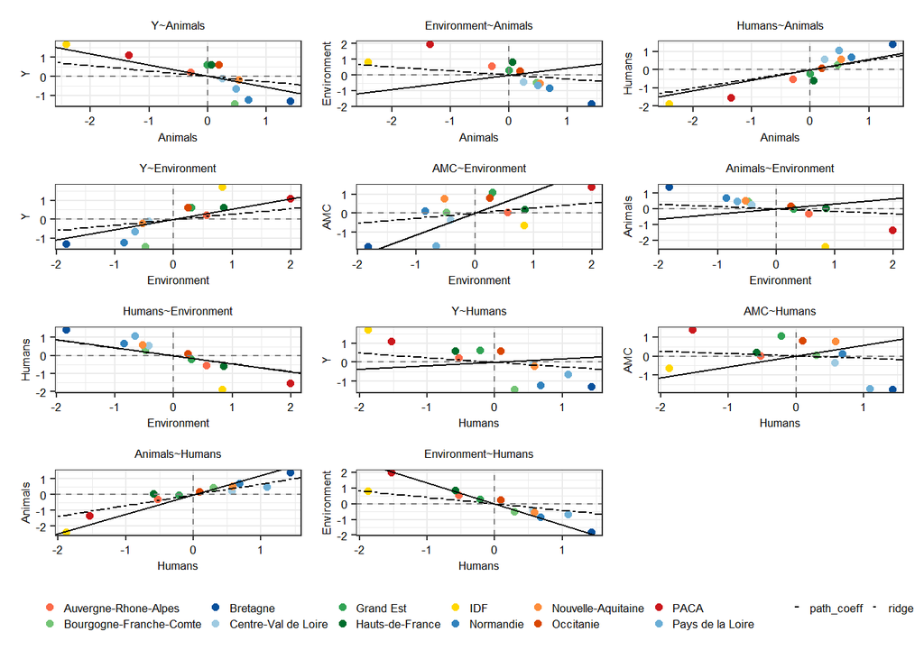

```r
# Appliquer à tous les liens
plot_list <- map(terms, make_scatter2, tab_ridge = tab_ridge) %>%
  set_names(terms)

wrap_plots(plot_list, ncol = 3) +
  plot_layout(guides = "collect") &
  theme(legend.position = "bottom") &
  guides(col = guide_legend(nrow = 2, override.aes = list(size = 1.6)))
```

## 3.4 AMR EHPAD C3G

### 3.4.1 Unidimensionalité des blocks

Le block “Animals” n’a pas l’air unidimensionnel.

```r
dfPC1.AMR_EHPAD_C3G <- scale(dfPC1.AMR_EHPAD_C3G) # standardisation

# Hypothèse d'unidimensionalité des blocks
Xnorm.block <- list(dfPC1.AMR_EHPAD_C3G[,which(colnames(dfPC1.AMR_EHPAD_C3G) %in% c("log_AMC_EHPAD_C3G", "log_AMC_ville_totale"))],
                    dfPC1.AMR_EHPAD_C3G[,which(colnames(dfPC1.AMR_EHPAD_C3G) %in% c("AMR_animaux_production_C3G_R", "tx_possession_chats", "tx_possession_chevaux", "log_UGB_density_volailles"))],
                    dfPC1.AMR_EHPAD_C3G[,which(colnames(dfPC1.AMR_EHPAD_C3G) %in% c("air_PM25_pop", "dju_refroi"))],
                    dfPC1.AMR_EHPAD_C3G[,which(colnames(dfPC1.AMR_EHPAD_C3G) %in% c("medecin_hab", "pop_75_plus_prop"))]
                    )

nb.block <- length(Xnorm.block)
order_blocks <- c("AMC", "Animals", "Environment", "Humans")
eigen <- lapply(1:nb.block, function(k) FactoMineR::PCA(Xnorm.block[[k]], scale.unit = TRUE, ncp = 2, graph = F)$eig)
perc_var_comp1 <- c()
for(i in 1:nb.block){
  perc_var_comp1 <- c(perc_var_comp1, eigen[[i]][1,2])
}
df.unim <- data.frame(order_blocks,
                      percentage_variance_PCA_comp1 = round(perc_var_comp1, 2))
knitr::kable(df.unim)
```

| order_blocks | percentage_variance_PCA_comp1 |
| --- | --- |
| AMC | 80.78 |
| Animals | 39.21 |
| Environment | 52.24 |
| Humans | 50.54 |

### 3.4.2 Paths coeffs

Pour le modèle intermédiaire, on retire le lien Y ~ Animals car le path coeff est proche de 0.

```r
model_simple <- paste(
  paste("Y =~", colnames(dfPC1.AMR_EHPAD_C3G)[1]),
  "AMC =~ log_AMC_EHPAD_C3G + log_AMC_ville_totale",
  "Animals =~ AMR_animaux_production_C3G_R + tx_possession_chats + log_UGB_density_volailles + tx_possession_chevaux",
  "Environment =~ dju_refroi + air_PM25_pop",
  "Humans =~ medecin_hab + pop_75_plus_prop",
  "Y ~ AMC + Animals + Environment + Humans",
  sep = "\n\t\t"
)

model_complet <- paste(
  paste("Y =~", colnames(dfPC1.AMR_EHPAD_C3G)[1]),
  "AMC =~ log_AMC_EHPAD_C3G + log_AMC_ville_totale",
  "Animals =~ AMR_animaux_production_C3G_R + tx_possession_chats + log_UGB_density_volailles + tx_possession_chevaux",
  "Environment =~ dju_refroi + air_PM25_pop",
  "Humans =~ medecin_hab + pop_75_plus_prop",
  "Y ~ AMC + Animals + Environment + Humans",
  "AMC ~ Humans + Environment",
  "Environment ~ Animals + Humans",
  "Humans ~ Environment + Animals",
  "Animals ~ Environment + Humans",
  sep = "\n\t\t"
)

model_int <- paste(
  paste("Y =~", colnames(dfPC1.AMR_EHPAD_C3G)[1]),
  "AMC =~ log_AMC_EHPAD_C3G + log_AMC_ville_totale",
  "Animals =~ AMR_animaux_production_C3G_R + tx_possession_chats + log_UGB_density_volailles + tx_possession_chevaux",
  "Environment =~ dju_refroi + air_PM25_pop",
  "Humans =~ medecin_hab + pop_75_plus_prop",
  "Y ~ AMC + Environment + Humans",
  "AMC ~ Humans + Environment",
  "Environment ~ Animals + Humans",
  "Humans ~ Environment + Animals",
  "Animals ~ Environment + Humans",
  sep = "\n\t\t"
)


set.seed(123)
mod_complet <- gesca::gesca.run(model_complet, dfPC1.AMR_EHPAD_C3G, nbt = 100)
sum_gsca_complet <- summary_gesca2(mod_complet)
mod_simple <- gesca::gesca.run(model_simple, dfPC1.AMR_EHPAD_C3G, nbt = 100)
sum_gsca_simple <- summary_gesca2(mod_simple)
mod_int <- gesca::gesca.run(model_int, dfPC1.AMR_EHPAD_C3G, nbt = 15)
sum_gsca_int <- summary_gesca2(mod_int)

paths_complet <- sum_gsca_complet$paths
paths_complet$model <- rep("complet", nrow(paths_complet))
paths_simple <- sum_gsca_simple$paths
paths_simple$model <- rep("simple", nrow(paths_simple))
paths_int <- sum_gsca_int$paths
paths_int$model <- rep("int", nrow(paths_int))
paths <- rbind.data.frame(paths_complet, paths_simple, paths_int)

DT::datatable(paths)
```

|  | group | term | estimate | std.error | ci_lb | ci_ub | model |
| --- | --- | --- | --- | --- | --- | --- | --- |
| 1 | all | Y~AMC | 0.2087 | 8.5714 | -28.6745 | 7.1956 | complet |
| 2 | all | Y~Animals | 0.0593 | 23.4656 | -35.2836 | 72.2302 | complet |
| 3 | all | Environment~Animals | -1.0213 | 1.0622 | -1.9222 | 2.3146 | complet |
| 4 | all | Humans~Animals | 1.0605 | 1.3619 | -2.6048 | 2.5014 | complet |
| 5 | all | Y~Environment | 0.4346 | 36.7496 | -80.0565 | 51.05 | complet |
| 6 | all | AMC~Environment | 0.3801 | 1.049 | -1.7558 | 2.708 | complet |
| 7 | all | Animals~Environment | -0.6584 | 1.2481 | -2.3289 | 2.5114 | complet |
| 8 | all | Humans~Environment | 0.309 | 1.3083 | -1.8761 | 2.3449 | complet |
| 9 | all | Y~Humans | -0.5422 | 30.9786 | -107.015 | 57.9006 | complet |
| 10 | all | AMC~Humans | -0.1233 | 1.1305 | -2.6686 | 2.4106 | complet |

[output cut: 17 more lines]

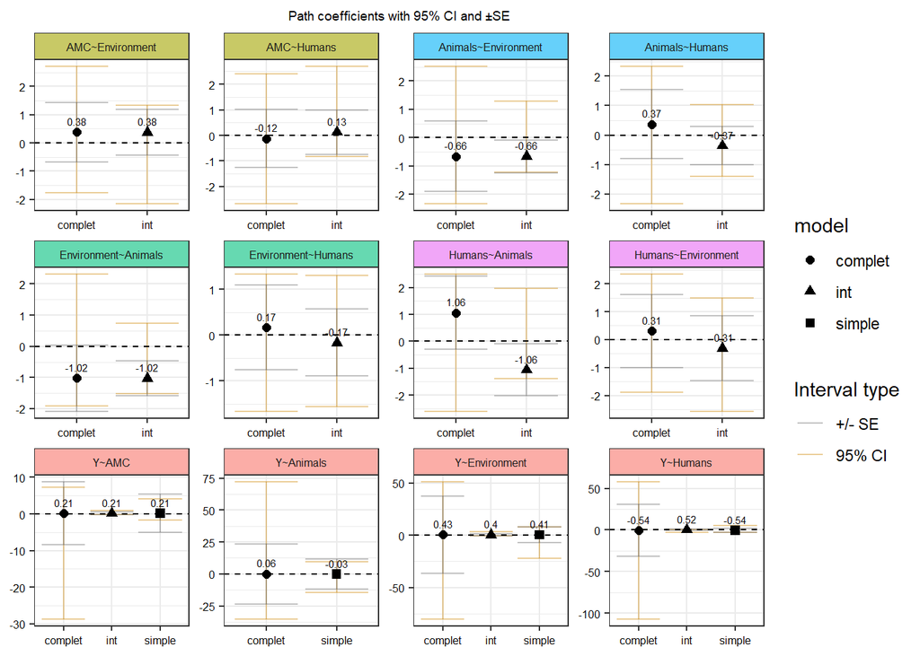

```r
paths$outcome <- str_remove(paths$term, "~.*")

outcomes <- unique(paths$outcome)
pal <- setNames(c("#F8766D", "#00BF7D", "#E76BF3",
                  "#A3A500", "#00B0F6"), outcomes)

term_outcome_map <- setNames(paths$outcome, paths$term)
term_levels <- sort(unique(paths$term))
# applique 0.6 d'opacité à chaque couleur de la palette
pal_alpha <- scales::alpha(pal, 0.6)
strip_colors <- pal_alpha[term_outcome_map[term_levels]]


ggplot(paths, aes(x = model, y = estimate)) +
    geom_errorbar(aes(ymin = ci_lb, ymax = ci_ub, color = "95% CI"),
                   height = 0.1, alpha = 0.4) +
    geom_errorbar(aes(ymin = estimate - std.error,
                       ymax = estimate + std.error,
                       color = "+/- SE"),
                   height = 0.1, linewidth = 0.4, alpha = 0.4) +
    geom_point(aes(shape = model), size = 2) +
    geom_text(aes(label = round(estimate, 2)),
              size = 2, vjust = -0.86)+
    geom_hline(yintercept = 0, linetype = "dashed") +
    ggh4x::facet_wrap2(~ term, scales = "free",
                       strip = strip_themed(
      background_x = elem_list_rect(fill = strip_colors)
    ))+
    theme_bw() +
    labs(title = "Path coefficients with 95% CI and ±SE")+
    theme(axis.text = element_text(color = "black", size = 6),
          axis.title = element_blank(),
          plot.title = element_text(hjust = 0.5, size = 7),
          strip.text = element_text(size = 6))+
  scale_color_manual(name = "Interval type",
                     values = c(
                       "95% CI" = "orange3",
                       "+/- SE" = "grey40"))
```

### 3.4.3 Loadings

```r
loadings_complet <- sum_gsca_complet$loadings
loadings_complet$model <- rep("complet", nrow(loadings_complet))
loadings_simple <- sum_gsca_simple$loadings
loadings_simple$model <- rep("simple", nrow(loadings_simple))
loadings_int <- sum_gsca_int$loadings
loadings_int$model <- rep("int", nrow(loadings_int))
loadings <- rbind.data.frame(loadings_complet, loadings_simple, loadings_int)

DT::datatable(loadings)
```

|  | group | term | estimate | std.error | ci_lb | ci_ub | model |
| --- | --- | --- | --- | --- | --- | --- | --- |
| 1 | all | AMR_EHPAD_C3G_R | 1 | 0 | 1 | 1 | complet |
| 2 | all | log_AMC_EHPAD_C3G | 0.801 | 0.8223 | -0.9966 | 0.9845 | complet |
| 3 | all | log_AMC_ville_totale | 0.9648 | 0.9104 | -0.9988 | 0.9972 | complet |
| 4 | all | AMR_animaux_production_C3G_R | 0.2234 | 0.4567 | -0.8507 | 0.9244 | complet |
| 5 | all | tx_possession_chats | 0.0873 | 0.5405 | -0.8641 | 0.9227 | complet |
| 6 | all | tx_possession_chevaux | 0.8646 | 0.6343 | -0.8811 | 0.9434 | complet |
| 7 | all | log_UGB_density_volailles | 0.7082 | 0.6767 | -0.9452 | 0.9553 | complet |
| 8 | all | air_PM25_pop | 0.906 | 0.7035 | -0.9827 | 0.9998 | complet |
| 9 | all | dju_refroi | 0.4634 | 0.6496 | -0.9003 | 0.9845 | complet |
| 10 | all | medecin_hab | -0.8764 | 0.7786 | -0.9984 | 0.9913 | complet |

[output cut: 23 more lines]

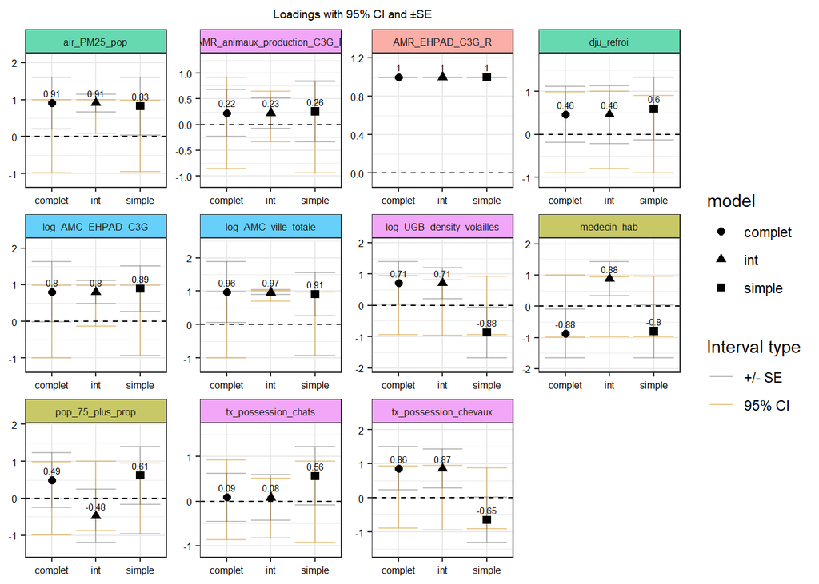

```r
loadings <- loadings %>% dplyr::left_join(correspondance_block,
                              by = "term")
loadings$block <- ifelse(is.na(loadings$block),
                         "Y", loadings$block)

blocks <- unique(loadings$block)
pal <- setNames(c("#F8766D", "#00B0F6", "#E76BF3",
                  "#00BF7D", "#A3A500"), blocks)
term_loadings_map <- setNames(loadings$block, loadings$term)
term_levels <- sort(unique(loadings$term))
# applique 0.6 d'opacité à chaque couleur de la palette
pal_alpha <- scales::alpha(pal, 0.6)
strip_colors <- pal_alpha[term_loadings_map[term_levels]]


ggplot(loadings, aes(x = model, y = estimate)) +
    geom_errorbar(aes(ymin = ci_lb, ymax = ci_ub, color = "95% CI"),
                   height = 0.1, alpha = 0.4) +
    geom_errorbar(aes(ymin = estimate - std.error,
                       ymax = estimate + std.error,
                       color = "+/- SE"),
                   height = 0.1, linewidth = 0.4, alpha = 0.4) +
    geom_point(aes(shape = model), size = 2) +
    geom_text(aes(label = round(estimate, 2)), size = 2, vjust = -0.86)+
    geom_hline(yintercept = 0, linetype = "dashed") +
    ggh4x::facet_wrap2(~ term, scales = "free",
                       strip = strip_themed(
      background_x = elem_list_rect(fill = strip_colors)
    ))+
    theme_bw() +
    scale_y_continuous(expand = expansion(mult = c(0.15, 0.25)))+
    labs(title = "Loadings with 95% CI and ±SE")+
    theme(axis.text = element_text(color = "black", size = 6),
          axis.title = element_blank(),
          plot.title = element_text(hjust = 0.5, size = 7),
          strip.text = element_text(size = 6))+
  scale_color_manual(name = "Interval type",
                     values = c(
                       "95% CI" = "orange3",
                       "+/- SE" = "grey40"))
```

### 3.4.4 Weight

```r
weights_complet <- sum_gsca_complet$weights
weights_complet$model <- rep("complet", nrow(weights_complet))
weights_simple <- sum_gsca_simple$weights
weights_simple$model <- rep("simple", nrow(weights_simple))
weights_int <- sum_gsca_int$weights
weights_int$model <- rep("int", nrow(weights_int))
weights <- rbind.data.frame(weights_complet, weights_simple, weights_int)

DT::datatable(weights)
```

|  | group | term | estimate | std.error | ci_lb | ci_ub | model |
| --- | --- | --- | --- | --- | --- | --- | --- |
| 1 | all | AMR_EHPAD_C3G_R | 1 | 0 | 1 | 1 | complet |
| 2 | all | log_AMC_EHPAD_C3G | 0.3333 | 0.5215 | -0.8859 | 0.9754 | complet |
| 3 | all | log_AMC_ville_totale | 0.7597 | 0.7058 | -0.9831 | 0.9974 | complet |
| 4 | all | AMR_animaux_production_C3G_R | 0.2511 | 0.3269 | -0.586 | 0.7486 | complet |
| 5 | all | tx_possession_chats | 0.2182 | 0.3894 | -0.7381 | 0.8055 | complet |
| 6 | all | tx_possession_chevaux | 0.644 | 0.5284 | -0.7347 | 0.9032 | complet |
| 7 | all | log_UGB_density_volailles | 0.5197 | 0.4654 | -0.8087 | 0.8165 | complet |
| 8 | all | air_PM25_pop | 0.8874 | 0.6492 | -1.0023 | 1.0137 | complet |
| 9 | all | dju_refroi | 0.423 | 0.5129 | -0.8467 | 0.9411 | complet |
| 10 | all | medecin_hab | -0.8719 | 0.6862 | -1.0715 | 0.9724 | complet |

[output cut: 23 more lines]

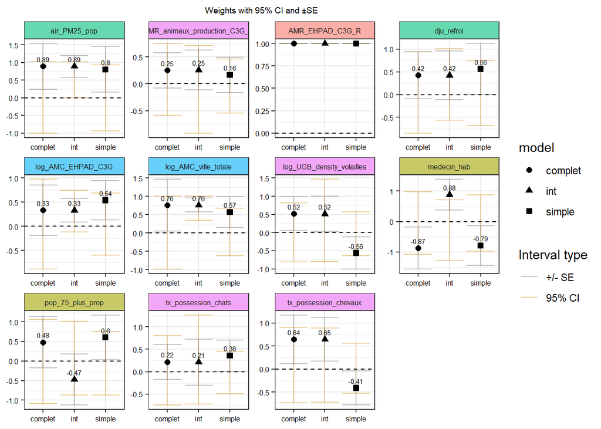

```r
weights <- weights %>% dplyr::left_join(correspondance_block,
                              by = "term")
weights$block <- ifelse(is.na(weights$block),
                         "Y", weights$block)

blocks <- unique(weights$block)
pal <- setNames(c("#F8766D", "#00B0F6", "#E76BF3",
                  "#00BF7D", "#A3A500"), blocks)
term_weights_map <- setNames(weights$block, weights$term)
term_levels <- sort(unique(weights$term))
# applique 0.6 d'opacité à chaque couleur de la palette
pal_alpha <- scales::alpha(pal, 0.6)
strip_colors <- pal_alpha[term_loadings_map[term_levels]]


ggplot(weights, aes(x = model, y = estimate)) +
    geom_errorbar(aes(ymin = ci_lb, ymax = ci_ub, color = "95% CI"),
                   height = 0.1, alpha = 0.4) +
    geom_errorbar(aes(ymin = estimate - std.error,
                       ymax = estimate + std.error,
                       color = "+/- SE"),
                   height = 0.1, linewidth = 0.4, alpha = 0.4) +
   geom_text(aes(label = round(estimate, 2)), size = 2,
            vjust = -0.86) +
    geom_point(aes(shape = model), size = 2) +
    geom_hline(yintercept = 0, linetype = "dashed") +
    ggh4x::facet_wrap2(~ term, scales = "free",
                       strip = strip_themed(
      background_x = elem_list_rect(fill = strip_colors)))+
    theme_bw() +
    labs(title = "Weights with 95% CI and ±SE")+
    theme(axis.text = element_text(color = "black", size = 6),
          axis.title = element_blank(),
          plot.title = element_text(hjust = 0.5, size = 7),
          strip.text = element_text(size = 6))+
  scale_color_manual(name = "Interval type",
                     values = c(
                       "95% CI" = "orange3",
                       "+/- SE" = "grey40"))
```

### 3.4.5 R2

```r
# corrélations entre composantes latentes
# complet
latentcorr_complet <- mod_complet$latentcorr
rownames(latentcorr_complet) <- c("Y", "AMC", "Animals", "Environment", "Humans")
colnames(latentcorr_complet) <- c("Y", "AMC", "Animals", "Environment", "Humans")
# int
latentcorr_int <- mod_int$latentcorr
rownames(latentcorr_int) <- c("Y", "AMC", "Animals", "Environment", "Humans")
colnames(latentcorr_int) <- c("Y", "AMC", "Animals", "Environment", "Humans")
# simple
latentcorr_simple <- mod_simple$latentcorr
rownames(latentcorr_simple) <- c("Y", "AMC", "Animals", "Environment", "Humans")
colnames(latentcorr_simple) <- c("Y", "AMC", "Animals", "Environment", "Humans")

R2 <- data.frame(term = sum_gsca_complet$paths$term,
                 R2_model_complet = rep(NA, length(sum_gsca_complet$paths$term)),
                 R2_model_int = rep(NA, length(sum_gsca_complet$paths$term)),
                 R2_model_simple = rep(NA, length(sum_gsca_complet$paths$term)))

for (i in 1:nrow(R2)){
  # complet
  beta_comp_block <- sum_gsca_complet$paths$estimate[sum_gsca_complet$paths$term == R2$term[i]]
r_block_comp <- latentcorr_complet[stringr::str_split(R2$term[i], "~")[[1]][1], stringr::str_split(R2$term[i], "~")[[1]][2]]
R2[i,]$R2_model_complet <- beta_comp_block * r_block_comp
# intermédiaire
if (R2$term[i] %in% sum_gsca_int$paths$term){
beta_int_block <- sum_gsca_int$paths$estimate[sum_gsca_int$paths$term == R2$term[i]]
r_block_int <- latentcorr_int[stringr::str_split(R2$term[i], "~")[[1]][1], stringr::str_split(R2$term[i], "~")[[1]][2]]
R2[i,]$R2_model_int <- beta_int_block * r_block_int}
else {R2[i,]$R2_model_int <- NA}
# simple
if (R2$term[i] %in% sum_gsca_simple$paths$term){
beta_simple_block <- sum_gsca_simple$paths$estimate[sum_gsca_simple$paths$term == R2$term[i]]
r_block_simple <- latentcorr_simple[stringr::str_split(R2$term[i], "~")[[1]][1], stringr::str_split(R2$term[i], "~")[[1]][2]]
R2[i,]$R2_model_simple <- beta_simple_block * r_block_simple}
else {R2[i,]$R2_model_simple <- NA}
}

knitr::kable(R2, digits = 2)
```

| term | R2_model_complet | R2_model_int | R2_model_simple |
| --- | --- | --- | --- |
| Y~AMC | 0.12 | 0.12 | 0.11 |
| Y~Animals | -0.05 | NA | -0.02 |
| Environment~Animals | 0.91 | 0.91 | NA |
| Humans~Animals | 0.83 | 0.83 | NA |
| Y~Environment | 0.36 | 0.33 | 0.34 |
| AMC~Environment | 0.17 | 0.17 | NA |
| Animals~Environment | 0.59 | 0.59 | NA |
| Humans~Environment | -0.20 | -0.20 | NA |
| Y~Humans | 0.46 | 0.44 | 0.45 |
| AMC~Humans | 0.05 | 0.05 | NA |
| Animals~Humans | 0.29 | 0.29 | NA |
| Environment~Humans | -0.11 | -0.11 | NA |

```r
# Les R2 par blocs
r2 <- data.frame(
  var = c("Y", "AMC", "Animals", "Environment", "Humans"),
  R2_model_complet = round(mod_complet$R2[1,], 2),
  R2_model_int = round(mod_int$R2[1,], 2),
  R2_model_simple = round(mod_simple$R2[1,], 2)
)

knitr::kable(r2)
```

| var | R2_model_complet | R2_model_int | R2_model_simple |
| --- | --- | --- | --- |
| Y | 0.89 | 0.89 | 0.88 |
| AMC | 0.22 | 0.22 | 0.00 |
| Animals | 0.87 | 0.87 | 0.00 |
| Environment | 0.81 | 0.80 | 0.00 |
| Humans | 0.64 | 0.64 | 0.00 |

### 3.4.6 Fit

```r
fit_complet <- featmeasures2(mod_complet)
```

```
##   Number of parameters        34
##   Number of bootstrap samples 100
##
##  Measure Estimate   Std.Error         CI_LB    CI_UB
##      FIT   0.5842 4.47000e-02        0.5938   0.7782
##     AFIT   0.4399 6.02000e-02        0.4529   0.7012
##      GFI -33.9123 2.66227e+07 -2056361.8857 -30.2742
##     SRMR   0.5070 8.91000e-02        0.3900   0.7237
##    FIT_M   0.5385 5.72000e-02        0.4902   0.7269
##    FIT_S   0.6846 6.47000e-02        0.6935   0.9763
```

```r
fit_complet$model <- rep("complet", nrow(fit_complet))
fit_simple <- featmeasures2(mod_simple)
```

```
##   Number of parameters        26
##   Number of bootstrap samples 100
##
##  Measure Estimate    Std.Error        CI_LB  CI_UB
##      FIT   0.4447       0.0401       0.4253 0.5826
##     AFIT   0.3084       0.0499       0.2844 0.4803
##      GFI   0.9597 1659743.8846 -190183.3231 0.9893
##     SRMR   0.3341       0.0524       0.3334 0.5423
##    FIT_M   0.5670       0.0570       0.5312 0.7609
##    FIT_S   0.1756       0.0175       0.1281 0.2000
```

```r
fit_simple$model <- rep("simple", nrow(fit_simple))
fit_int <- featmeasures2(mod_int)
```

```
##   Number of parameters        33
##   Number of bootstrap samples 15
##
##  Measure Estimate Std.Error       CI_LB    CI_UB
##      FIT   0.5842    0.0567      0.5756   0.8051
##     AFIT   0.4456    0.0756      0.4341   0.7401
##      GFI -34.1664 5444.5376 -21328.5852 -19.6762
##     SRMR   0.5050    0.0889      0.3931   0.7043
##    FIT_M   0.5385    0.0640      0.4733   0.7471
##    FIT_S   0.6845    0.0674      0.7250   0.9361
```

```r
fit_int$model <- rep("int", nrow(fit_int))
fit <- rbind.data.frame(fit_complet, fit_simple, fit_int)

DT::datatable(fit)
```

|  | Measure | Estimate | Std.Error | CI_LB | CI_UB | model |
| --- | --- | --- | --- | --- | --- | --- |
| 1 | FIT | 0.5842 | 0.0447 | 0.5938 | 0.7782 | complet |
| 2 | AFIT | 0.4399 | 0.0602 | 0.4529 | 0.7012 | complet |
| 3 | GFI | -33.9123 | 26622696.811 | -2056361.8857 | -30.2742 | complet |
| 4 | SRMR | 0.507 | 0.0891 | 0.39 | 0.7237 | complet |
| 5 | FIT_M | 0.5385 | 0.0572 | 0.4902 | 0.7269 | complet |
| 6 | FIT_S | 0.6846 | 0.0647 | 0.6935 | 0.9763 | complet |
| 7 | FIT | 0.4447 | 0.0401 | 0.4253 | 0.5826 | simple |
| 8 | AFIT | 0.3084 | 0.0499 | 0.2844 | 0.4803 | simple |
| 9 | GFI | 0.9597 | 1659743.8846 | -190183.3231 | 0.9893 | simple |
| 10 | SRMR | 0.3341 | 0.0524 | 0.3334 | 0.5423 | simple |

[output cut: 8 more lines]

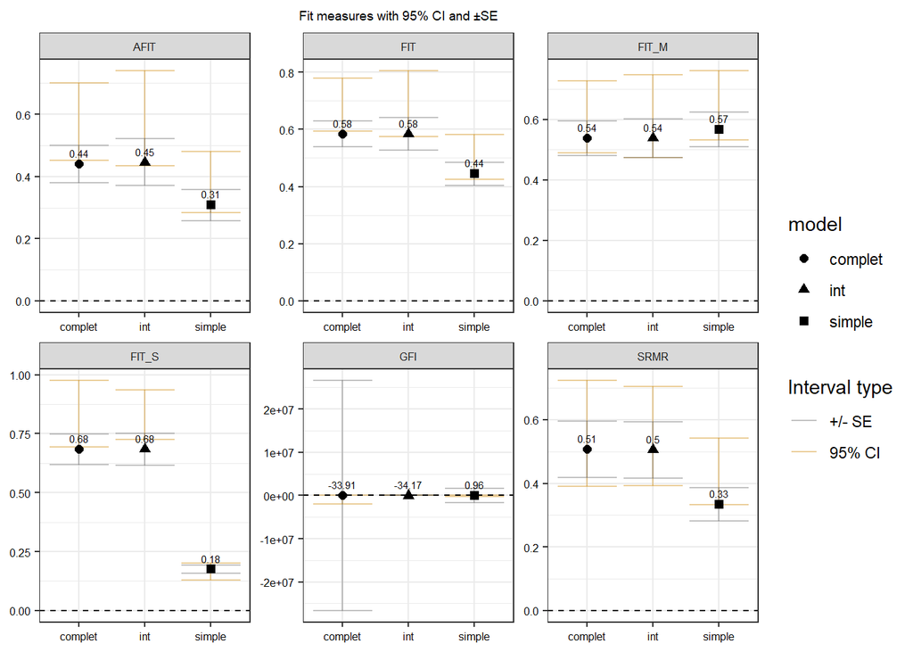

```r
ggplot(fit, aes(x = model, y = Estimate)) +
    geom_errorbar(aes(ymin = CI_LB, ymax = CI_UB, color = "95% CI"),
                   height = 0.1, alpha = 0.4) +
    geom_errorbar(aes(ymin = Estimate - Std.Error,
                       ymax = Estimate + Std.Error,
                       color = "+/- SE"),
                   height = 0.1, linewidth = 0.4, alpha = 0.4) +
    geom_point(aes(shape = model), size = 2) +
    geom_text(aes(label = round(Estimate, 2)), size = 2, vjust = -0.86)+
    geom_hline(yintercept = 0, linetype = "dashed") +
    facet_wrap(~ Measure, scales = "free")+
    theme_bw() +
    labs(title = "Fit measures with 95% CI and ±SE")+
    theme(axis.text = element_text(color = "black", size = 6),
          axis.title = element_blank(),
          plot.title = element_text(hjust = 0.5, size = 7),
          strip.text = element_text(size = 6))+
  scale_color_manual(name = "Interval type",
                     values = c(
                       "95% CI" = "orange3",
                       "+/- SE" = "grey40"))
```

### 3.4.7 Scatterplot VL

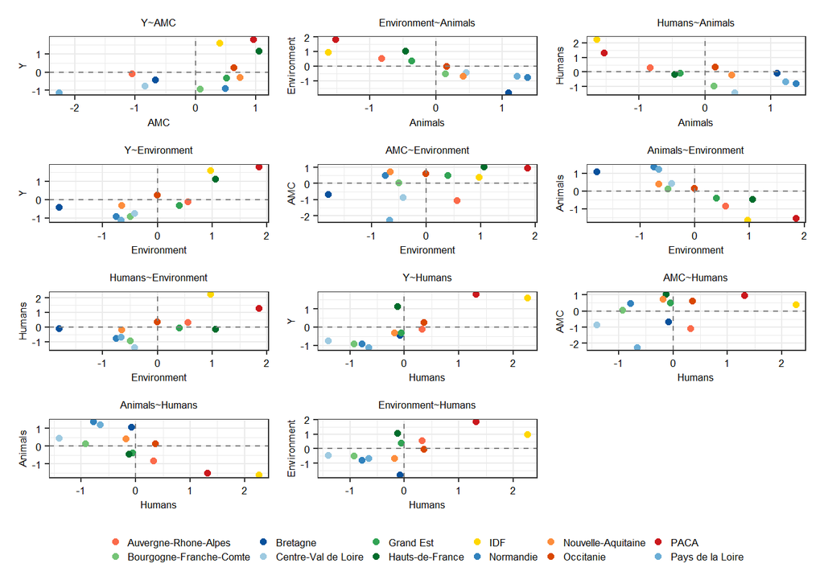

```r
#dimnames(mod_int$WR)
rownames(mod_int$WR) <- sum_gsca_int$weights$term
colnames(mod_int$WR) <- c("Y", "AMC", "Animals",
                          "Environment", "Humans")

indicateur <- rownames(mod_int$WR)
X <- scale(dfPC1.AMR_EHPAD_C3G[, indicateur])
latent_coord <- X %*% mod_int$WR

# 1. Transformer la matrice en data frame avec une colonne "id" pour la couleur
df_coord <- as.data.frame(latent_coord) %>%
  rownames_to_column("id")

# 2. Récupérer les termes
terms <- sum_gsca_int$paths$term

plot_list <- map(terms, make_scatter) %>%
  set_names(terms)

wrap_plots(plot_list, ncol = 3) +
  plot_layout(guides = "collect") &
  theme(legend.position = "bottom") &
  guides(col = guide_legend(nrow = 2, override.aes = list(size = 1.6)))
```

```r
# ggsave("C:/Users/g.martet/Documents/functional_study/figures diapo/scatterplot_VL_AMR_EHPAD_C3G.png", width = 7, height = 7)
```

### 3.4.8 graphes

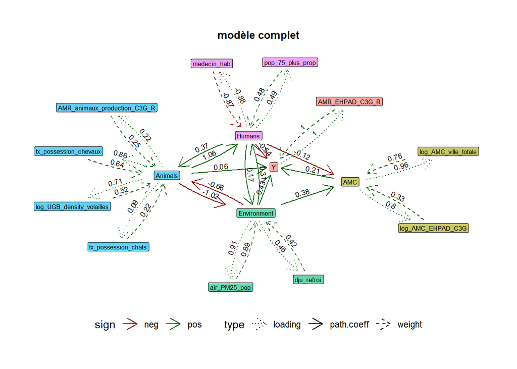

```r
#-----------------------
# construire le dataset
#-----------------------

# les paths
paths$from <- str_remove(paths$term, ".*~")
paths2 <- paths %>%
  dplyr::rename(to = "outcome") %>%
  dplyr::select(from, to, estimate, model) %>%
  dplyr::mutate(sign = ifelse(estimate >=0, "pos", "neg")) %>%
  dplyr::mutate(block = from) %>%
  dplyr::mutate(type = "path.coeff")
# les weights
weights2 <- weights %>%
  dplyr::rename(from = "term", to = "block") %>%
  dplyr::select(from, to, estimate, model) %>%
  dplyr::mutate(sign = ifelse(estimate >=0, "pos", "neg")) %>%
  dplyr::mutate(block = to) %>%
  dplyr::mutate(type = "weight")
# les loadings
loadings2 <- loadings %>%
  dplyr::rename(from = "block", to = "term") %>%
  dplyr::select(from, to, estimate, model) %>%
  dplyr::mutate(sign = ifelse(estimate >=0, "pos", "neg")) %>%
  dplyr::mutate(block = from) %>%
  dplyr::mutate(type = "loading")

dat_graph <- rbind(paths2, weights2, loadings2)

#----------------------
# modèle complet
#----------------------

dat_filtered <- dat_graph %>%
  dplyr::filter(model == "complet")

# Construire le tableau des noeuds avec leur block
nodes_df <- dplyr::bind_rows(
  dat_filtered %>% dplyr::select(name = from, block),
  dat_filtered %>% dplyr::select(name = to, block)
) %>%
  dplyr::filter(!is.na(block)) %>%   # garde les lignes où block est renseigné
  dplyr::distinct(name, .keep_all = TRUE)  # une ligne par noeud

# Construire le graphe explicitement
graph <- tbl_graph(
  nodes = nodes_df,
  edges = dat_filtered %>% dplyr::select(from, to, estimate, sign, type),
  node_key = "name"
)

g1 <- ggraph(graph) +
  geom_edge_fan(aes(colour = sign,
                     end_cap = label_rect(node2.name),
                     start_cap = label_rect(node1.name),
                    label = round(estimate, 2),
                    linetype = type),
                arrow = arrow(length = unit(4, 'mm')),
                label_dodge = unit(1.8, 'mm'),
                angle_calc = "along",
                label_size = 2.5) +
  geom_node_label(aes(label = name, fill = block), size = 2.2,
                  show.legend = FALSE, alpha = 0.6) +
  labs(title = "modèle complet")+
  scale_x_continuous(expand = expansion(mult = 0.10)) +
  ggraph::theme_graph(background = 'white') +
  theme(legend.position = "bottom") +
  theme(plot.title = element_text(hjust = 0.5, size = 10))+
  scale_edge_colour_manual(values = c("darkred", "darkgreen"))+
  scale_edge_linetype_manual(values = c(path.coeff = "solid", weight = "dashed", loading = "dotted"))+
  scale_fill_manual(values = c(Y = "#F8766D", Animals = "#00B0F6", Humans = "#E76BF3",
                  Environment = "#00BF7D", AMC = "#A3A500"))

#----------------------
# modèle intermédiaire
#----------------------

dat_filtered <- dat_graph %>%
  dplyr::filter(model == "int")

# Construire le tableau des noeuds avec leur block
nodes_df <- dplyr::bind_rows(
  dat_filtered %>% dplyr::select(name = from, block),
  dat_filtered %>% dplyr::select(name = to, block)
) %>%
  dplyr::filter(!is.na(block)) %>%   # garde les lignes où block est renseigné
  dplyr::distinct(name, .keep_all = TRUE)  # une ligne par noeud

# Construire le graphe explicitement
graph <- tbl_graph(
  nodes = nodes_df,
  edges = dat_filtered %>% dplyr::select(from, to, estimate, sign, type),
  node_key = "name"
)

g2 <- ggraph(graph) +
  geom_edge_fan(aes(colour = sign,
                     end_cap = label_rect(node2.name),
                     start_cap = label_rect(node1.name),
                    label = round(estimate, 2),
                    linetype = type),
                arrow = arrow(length = unit(4, 'mm')),
                label_dodge = unit(1.8, 'mm'),
                angle_calc = "along",
                label_size = 2.5) +
  geom_node_label(aes(label = name, fill = block), size = 2.2,
                  show.legend = FALSE, alpha = 0.6) +
  labs(title = "modèle intermédiaire")+
  ggraph::theme_graph(background = 'white') +
  theme(legend.position = "bottom") +
  scale_x_continuous(expand = expansion(mult = 0.10)) +
  theme(plot.title = element_text(hjust = 0.5, size = 10))+
  scale_edge_colour_manual(values = c("darkred", "darkgreen"))+
  scale_edge_linetype_manual(values = c(path.coeff = "solid", weight = "dashed", loading = "dotted"))+
  scale_fill_manual(values = c(Y = "#F8766D", Animals = "#00B0F6", Humans = "#E76BF3",
                  Environment = "#00BF7D", AMC = "#A3A500"))

#----------------------
# modèle simple
#----------------------

dat_filtered <- dat_graph %>%
  dplyr::filter(model == "simple")

# Construire le tableau des noeuds avec leur block
nodes_df <- dplyr::bind_rows(
  dat_filtered %>% dplyr::select(name = from, block),
  dat_filtered %>% dplyr::select(name = to, block)
) %>%
  dplyr::filter(!is.na(block)) %>%   # garde les lignes où block est renseigné
  dplyr::distinct(name, .keep_all = TRUE)  # une ligne par noeud

# Construire le graphe explicitement
graph <- tbl_graph(
  nodes = nodes_df,
  edges = dat_filtered %>% dplyr::select(from, to, estimate, sign, type),
  node_key = "name"
)

g3 <- ggraph(graph) +
  geom_edge_fan(aes(colour = sign,
                     end_cap = label_rect(node2.name),
                     start_cap = label_rect(node1.name),
                    label = round(estimate, 2),
                    linetype = type),
                arrow = arrow(length = unit(4, 'mm')),
                label_dodge = unit(1.8, 'mm'),
                angle_calc = "along",
                label_size = 2.5) +
  geom_node_label(aes(label = name, fill = block), size = 2.2,
                  show.legend = FALSE, alpha = 0.6) +
  labs(title = "modèle simple")+
  scale_x_continuous(expand = expansion(mult = 0.10)) +
  ggraph::theme_graph(background = 'white') +
  theme(legend.position = "bottom") +
  theme(plot.title = element_text(hjust = 0.5, size = 10))+
  scale_edge_colour_manual(values = c("darkred", "darkgreen"))+
  scale_edge_linetype_manual(values = c(path.coeff = "solid", weight = "dashed", loading = "dotted"))+
  scale_fill_manual(values = c(Y = "#F8766D", Animals = "#00B0F6", Humans = "#E76BF3",
                  Environment = "#00BF7D", AMC = "#A3A500"))

g1
```

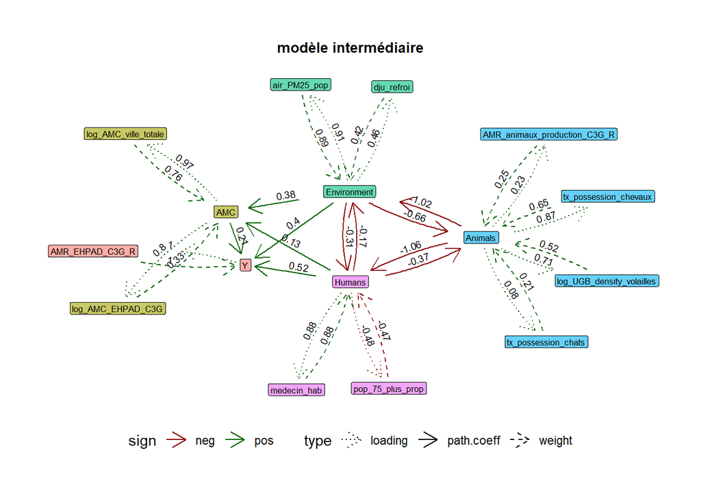

```r
g2
```

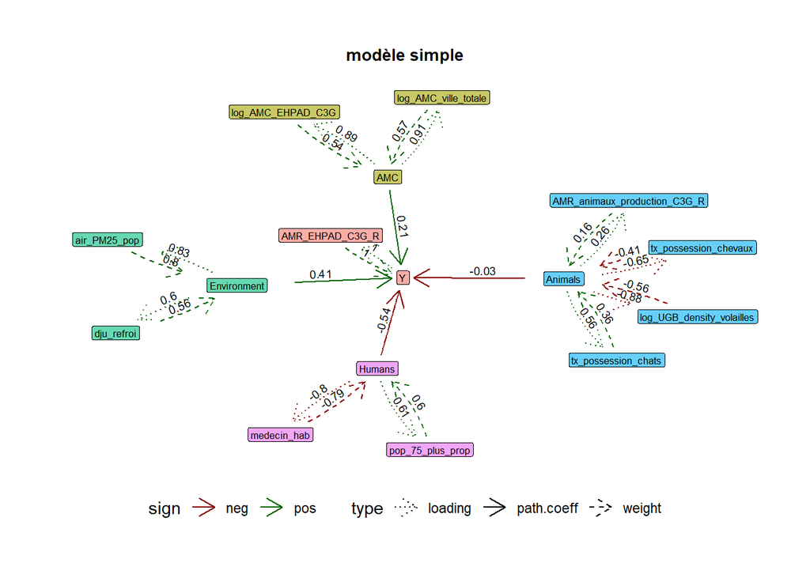

```r
g3
```

### 3.4.9 Coefficients de regression

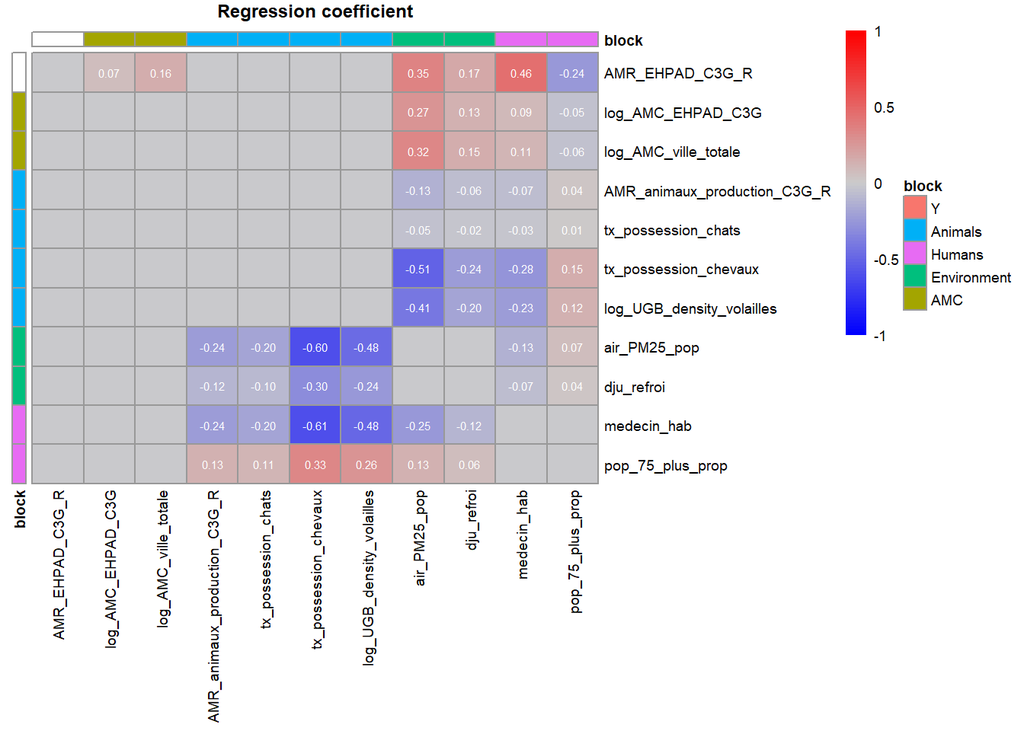

```r
M <- Matrix_reg(model_type = "int")

cl <- as.data.frame(correspondance_block[which(correspondance_block$term %in% colnames(M)),])
cl <- rbind.data.frame(cl,
data.frame(block = "Y", term = "AMR_ville_FQ_R"))
rownames(cl) <- cl$term
cl <- cl %>% dplyr::select(-term)

disp <- matrix(sprintf("%.2f", M), nrow = nrow(M), ncol = ncol(M))
disp[abs(M) == 0] <- ""

ann_colors <- list(
 block = c(
    Y = "#F8766D",
    Animals = "#00B0F6",
    Humans = "#E76BF3",
    Environment = "#00BF7D",
    AMC = "#A3A500"
  )
)

pheatmap::pheatmap(M,
                          color = colorRampPalette(c("blue", "grey80", "red"))(100),
                          breaks = seq(-1, 1, length.out = 101),
                          cluster_rows = FALSE,
                          cluster_cols = FALSE,
                          # clustering_distance_rows = "euclidean",
                          # clustering_distance_cols = "euclidean",
                          # clustering_method = "ward.D2",
                          number_format = "%.1f",
                          fontsize = 7,
                          number_color = "white",
                          legend = TRUE,
                          legend_breaks = c(-1, -0.5, 0, 0.5, 1),
                          legend_labels = c("-1", "-0.5", "0", "0.5", "1"),
                          angle_col = 90,
                          annotation_row = cl,
                          annotation_col = cl,
                          annotation_colors = ann_colors,
                          display_numbers = disp,
                          main = "Regression coefficient")
```

### 3.4.10 Regresssion Ridge VL

```r
submodels <- c("Y ~ AMC + Environment + Humans",
  "AMC ~ Humans + Environment",
  "Environment ~ Animals + Humans",
  "Humans ~ Environment + Animals",
  "Animals ~ Environment + Humans")

tab_ridge <- sum_gsca_int$paths %>%
  dplyr::select(term, path_coeff = estimate) %>%
  dplyr::arrange(desc(term))

# Application à tous les submodels + assemblage
ridge_results <- purrr::map_dfr(submodels, get_ridge_betas, data = latent_coord)

# Jointure avec ton tableau initial
tab_ridge <- tab_ridge %>%
  dplyr::left_join(ridge_results, by = "term")

knitr::kable(tab_ridge, digits = 2)
```

| term | path_coeff | ridge_beta |
| --- | --- | --- |
| Y~Humans | 0.52 | 0.43 |
| Y~Environment | 0.40 | 0.36 |
| Y~AMC | 0.21 | 0.20 |
| Humans~Environment | -0.31 | -0.04 |
| Humans~Animals | -1.06 | -0.76 |
| Environment~Humans | -0.17 | -0.01 |
| Environment~Animals | -1.02 | -0.83 |
| Animals~Humans | -0.37 | -0.36 |
| Animals~Environment | -0.66 | -0.54 |
| AMC~Humans | 0.13 | 0.13 |
| AMC~Environment | 0.38 | 0.21 |

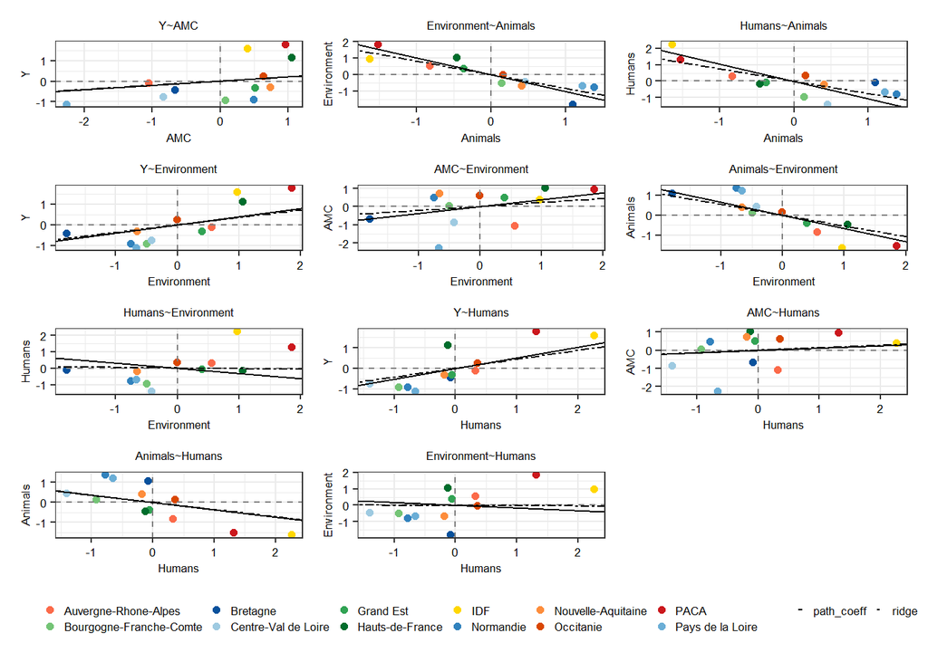

```r
# Appliquer à tous les liens
plot_list <- map(terms, make_scatter2, tab_ridge = tab_ridge) %>%
  set_names(terms)

wrap_plots(plot_list, ncol = 3) +
  plot_layout(guides = "collect") &
  theme(legend.position = "bottom") &
  guides(col = guide_legend(nrow = 2, override.aes = list(size = 1.6)))
```

## 3.5 AMR ES C3G

### 3.5.1 Unidimensionalité des blocks

Le block “Animals” n’a pas l’air unidimensionnel.

```r
dfPC1.AMR_ES_C3G <- scale(dfPC1.AMR_ES_C3G) # standardisation

# Hypothèse d'unidimensionalité des blocks
Xnorm.block <- list(dfPC1.AMR_ES_C3G[,which(colnames(dfPC1.AMR_ES_C3G) %in% c("log_AMC_ES_C3G", "log_AMC_ville_C3G"))],
                    dfPC1.AMR_ES_C3G[,which(colnames(dfPC1.AMR_ES_C3G) %in% c("AMR_animaux_production_C3G_R", "tx_possession_chats", "log_UGB_density_livestock_tot
", "log_UGB_density_volailles"))],
                    dfPC1.AMR_ES_C3G[,which(colnames(dfPC1.AMR_ES_C3G) %in% c("air_PM25_pop", "dju_refroi"))],
                    dfPC1.AMR_ES_C3G[,which(colnames(dfPC1.AMR_ES_C3G) %in% c("medecin_hab", "tx_pauvrete_60"))]
                    )

nb.block <- length(Xnorm.block)
order_blocks <- c("AMC", "Animals", "Environment", "Humans")
eigen <- lapply(1:nb.block, function(k) FactoMineR::PCA(Xnorm.block[[k]], scale.unit = TRUE, ncp = 2, graph = F)$eig)
perc_var_comp1 <- c()
for(i in 1:nb.block){
  perc_var_comp1 <- c(perc_var_comp1, eigen[[i]][1,2])
}
df.unim <- data.frame(order_blocks,
                      percentage_variance_PCA_comp1 = round(perc_var_comp1, 2))
knitr::kable(df.unim)
```

| order_blocks | percentage_variance_PCA_comp1 |
| --- | --- |
| AMC | 83.56 |
| Animals | 46.58 |
| Environment | 52.49 |
| Humans | 72.10 |